# Δ AUC under different models: type 2 diabetes, European-trained scores

### 5.3 Add a random effect for the sample set

```r
fit_sa_5_3
```

```
Multivariate Meta-Analysis Model (k = 31; method: REML)

Variance Components:

            estim    sqrt  nlvls  fixed  factor
sigma^2    0.0001  0.0095     11     no  cohort

Test for Residual Heterogeneity:
QE(df = 17) = 68.9410, p-val < .0001

Test of Moderators (coefficients 2:14):
QM(df = 13) = 710.5691, p-val < .0001

Model Results:

                     estimate      se      zval    pval    ci.lb    ci.ub
intrcpt                0.7354  0.0080   92.0887  <.0001   0.7198   0.7511  ***
ancestrySouth Asian   -0.0114  0.0073   -1.5515  0.1208  -0.0258   0.0030
PGSPGS000713          -0.0130  0.0033   -3.9871  <.0001  -0.0194  -0.0066  ***
PGSPGS000729          -0.0135  0.0033   -4.1330  <.0001  -0.0199  -0.0071  ***
PGSPGS000805          -0.0175  0.0033   -5.3733  <.0001  -0.0239  -0.0111  ***
PGSPGS000864          -0.0383  0.0033  -11.7173  <.0001  -0.0447  -0.0319  ***
PGSPGS000868          -0.0284  0.0033   -8.7122  <.0001  -0.0348  -0.0220  ***
PGSPGS001295          -0.0532  0.0128   -4.1490  <.0001  -0.0784  -0.0281  ***
PGSPGS001818          -0.0155  0.0033   -4.7607  <.0001  -0.0219  -0.0091  ***
PGSPGS002026          -0.0109  0.0033   -3.3515  0.0008  -0.0173  -0.0045  ***
PGSPGS002671          -0.0204  0.0031   -6.5662  <.0001  -0.0265  -0.0143  ***
PGSPGS002771           0.0097  0.0033    2.9900  0.0028   0.0034   0.0161   **
PGSPGS002780          -0.0301  0.0033   -9.2032  <.0001  -0.0365  -0.0237  ***
PGSPGS004106          -0.1664  0.0084  -19.7774  <.0001  -0.1829  -0.1500  ***

---
Signif. codes:  0 '***' 0.001 '**' 0.01 '*' 0.05 '.' 0.1 ' ' 1
```

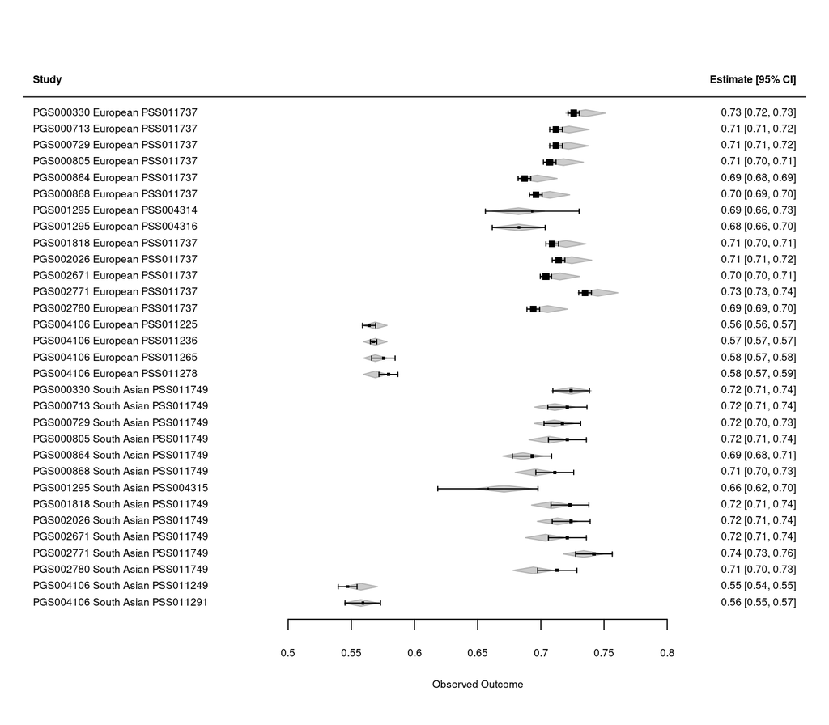

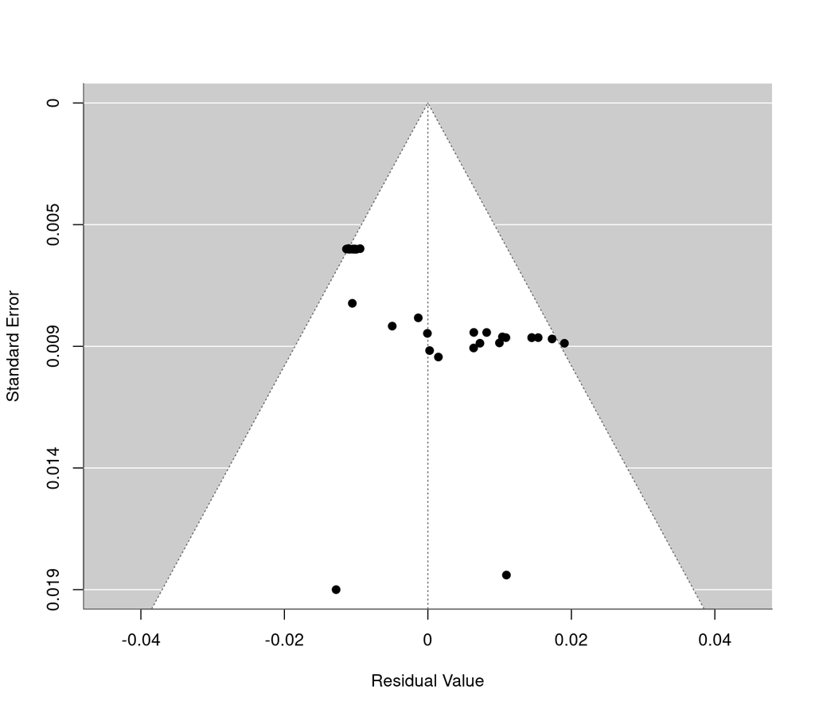

```
Profiling sigma2 = 1
```

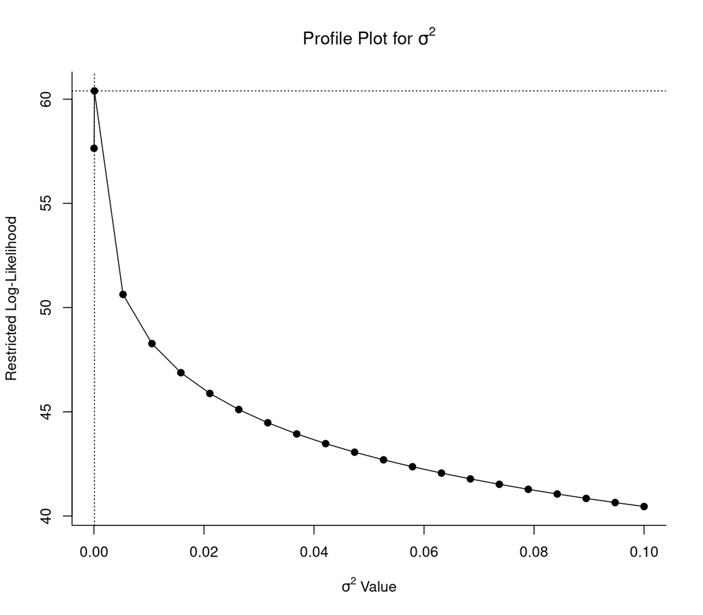

```r
diag_rma(fit_sa_5_3, sa)
```

### 5.4 Score and sample set as random effects

```r
fit_sa_5_4
```

```
Multivariate Meta-Analysis Model (k = 31; method: REML)

Variance Components:

            estim    sqrt  nlvls  fixed  factor
sigma^2.1  0.0018  0.0424     13     no     PGS
sigma^2.2  0.0001  0.0098     11     no  cohort

Test for Residual Heterogeneity:
QE(df = 29) = 13587.8560, p-val < .0001

Test of Moderators (coefficient 2):
QM(df = 1) = 1.9703, p-val = 0.1604

Model Results:

                     estimate      se     zval    pval    ci.lb   ci.ub
intrcpt                0.7012  0.0136  51.5860  <.0001   0.6746  0.7278  ***
ancestrySouth Asian   -0.0105  0.0075  -1.4037  0.1604  -0.0253  0.0042

---
Signif. codes:  0 '***' 0.001 '**' 0.01 '*' 0.05 '.' 0.1 ' ' 1
```

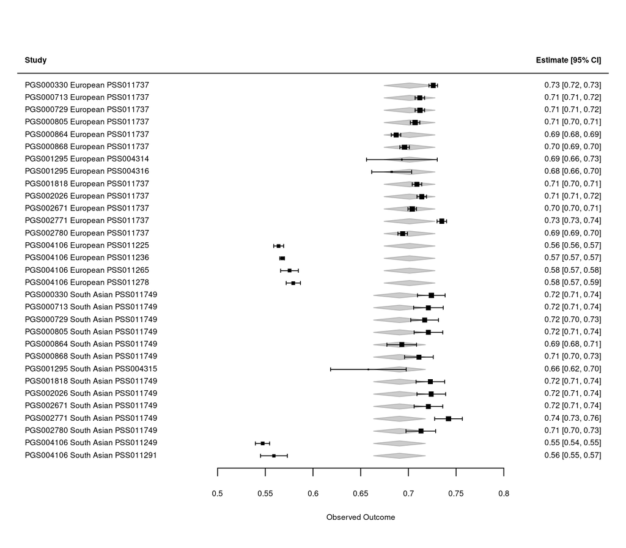

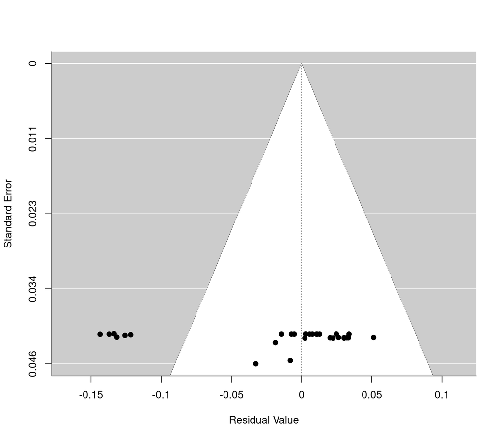

```
Profiling sigma2 = 1
```

```
Profiling sigma2 = 2
```

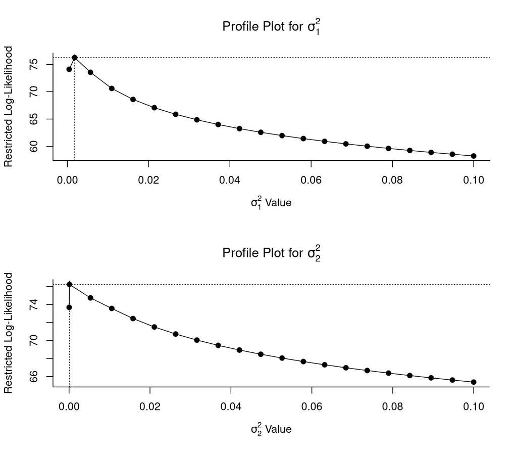

```r
diag_rma(fit_sa_5_4, sa)
```

**What we see.**

- This model has the same terms as the `lmer` model 3.5, but the two report different variance components:

```r
tibble(
  model = c("3.5 lmer", "5.4 rma.mv"),
  `score SD` = c(sa_vc35$sdcor[sa_vc35$grp == "PGS"], sqrt(fit_sa_5_4$sigma2[1])),
  `sample-set SD` = c(sa_vc35$sdcor[sa_vc35$grp == "cohort"], sqrt(fit_sa_5_4$sigma2[2])),
  `Δ AUC` = c(
    get_est("South Asian", "3.5 lmer(AUC ~ ancestry + (1|PGS) + (1|cohort)), weighted"),
    get_est("South Asian", "5.4 rma.mv(AUC ~ ancestry, random = 1|PGS + 1|cohort)")
  ),
  SE = c(
    get_est("South Asian", "3.5 lmer(AUC ~ ancestry + (1|PGS) + (1|cohort)), weighted", "se"),
    get_est("South Asian", "5.4 rma.mv(AUC ~ ancestry, random = 1|PGS + 1|cohort)", "se")
  )
) %>%
  kable(digits = 4)
```

| model | score SD | sample-set SD | Δ AUC | SE |
| --- | --- | --- | --- | --- |
| 3.5 lmer | 0.0142 | 0.0632 | -0.0043 | 0.0399 |
| 5.4 rma.mv | 0.0424 | 0.0098 | -0.0105 | 0.0075 |

- In 3.5 the sample-set SD is the larger of the two. Here the score SD is the larger.
- `lmer` gave no warning for 3.5. I don’t know whether 3.5 is a sound fit.

## All South Asian estimates side by side

```r
sa_models <- est_tbl %>% filter(comparison == "South Asian") %>% pull(model)
show_rows("South Asian", sa_models)
```

| model | scale | estimate (model scale) | SE (model scale) | σ | Δ AUC | SE (AUC) | 95% CI | note |
| --- | --- | --- | --- | --- | --- | --- | --- | --- |
| 1. IVW stage 1 → stage 2 | AUC | 0.00072 | 0.00199 | NA | 0.00072 | 0.00199 | -0.0032 to 0.0046 |  |
| 2.1 lm(logit ~ ancestry), weighted | logit | -0.00379 | 0.19845 | 21.69675 | -0.00086 | 0.04495 | -0.0890 to 0.0872 |  |
| 2.2 lm(logit ~ ancestry + PGS) | logit | 0.01165 | 0.01819 | 0.04980 | 0.00243 | 0.00379 | -0.0050 to 0.0099 |  |
| 2.3 lm(logit ~ ancestry + PGS), weighted | logit | -0.00309 | 0.01837 | 2.00774 | -0.00065 | 0.00386 | -0.0082 to 0.0069 |  |
| 2.4 lmer(logit ~ ancestry + PGS + (1\|cohort)), weighted | logit | -0.04927 | 0.02997 | 0.73633 | -0.01027 | 0.00625 | -0.0225 to 0.0020 |  |
| 2.5 lmer(logit ~ ancestry + (1\|PGS) + (1\|cohort)), weighted | logit | -0.04632 | 0.03063 | 0.73759 | -0.00977 | 0.00647 | -0.0224 to 0.0029 |  |
| 3.1 lm(AUC ~ ancestry), weighted | AUC | 0.00238 | 0.04311 | 21.64594 | 0.00238 | 0.04311 | -0.0821 to 0.0869 |  |
| 3.2 lm(AUC ~ ancestry + PGS) | AUC | 0.00166 | 0.00404 | 0.01108 | 0.00166 | 0.00404 | -0.0063 to 0.0096 |  |
| 3.3 lm(AUC ~ ancestry + PGS), weighted | AUC | 0.00072 | 0.00401 | 2.01379 | 0.00072 | 0.00401 | -0.0071 to 0.0086 |  |
| 3.4 lmer(AUC ~ ancestry + PGS + (1\|cohort)), weighted | AUC | -0.01232 | 0.00701 | 0.74776 | -0.01232 | 0.00701 | -0.0261 to 0.0014 | convergence warning |
| 3.5 lmer(AUC ~ ancestry + (1\|PGS) + (1\|cohort)), weighted | AUC | -0.00430 | 0.03990 | 0.77250 | -0.00430 | 0.03990 | -0.0825 to 0.0739 |  |
| 4.1 rma.mv(logit ~ ancestry) | logit | -0.00379 | 0.00915 | NA | -0.00086 | 0.00207 | -0.0049 to 0.0032 |  |
| 4.2 rma.mv(logit ~ ancestry + PGS) | logit | -0.00309 | 0.00915 | NA | -0.00065 | 0.00192 | -0.0044 to 0.0031 |  |
| 4.3 rma.mv(logit ~ ancestry + PGS, random = 1\|cohort) | logit | -0.04493 | 0.03127 | NA | -0.00937 | 0.00653 | -0.0222 to 0.0034 |  |
| 4.4 rma.mv(logit ~ ancestry, random = 1\|PGS + 1\|cohort) | logit | -0.04161 | 0.03192 | NA | -0.00878 | 0.00674 | -0.0220 to 0.0044 |  |
| 4.5 rma.mv(logit ~ ancestry + PGS, random = 1\|cohort/row) | logit | -0.04493 | 0.03127 | NA | -0.00937 | 0.00653 | -0.0222 to 0.0034 |  |
| 4.6 rma.mv(logit ~ ancestry + PGS, random = 1\|cohort/row), V with rho = 0.6 within study | logit | -0.06303 | 0.02818 | NA | -0.01324 | 0.00595 | -0.0249 to -0.0016 |  |
| 5.1 rma.mv(AUC ~ ancestry) | AUC | 0.00238 | 0.00199 | NA | 0.00238 | 0.00199 | -0.0015 to 0.0063 |  |
| 5.2 rma.mv(AUC ~ ancestry + PGS) | AUC | 0.00072 | 0.00199 | NA | 0.00072 | 0.00199 | -0.0032 to 0.0046 |  |
| 5.3 rma.mv(AUC ~ ancestry + PGS, random = 1\|cohort) | AUC | -0.01138 | 0.00734 | NA | -0.01138 | 0.00734 | -0.0258 to 0.0030 |  |
| 5.4 rma.mv(AUC ~ ancestry, random = 1\|PGS + 1\|cohort) | AUC | -0.01055 | 0.00751 | NA | -0.01055 | 0.00751 | -0.0253 to 0.0042 |  |

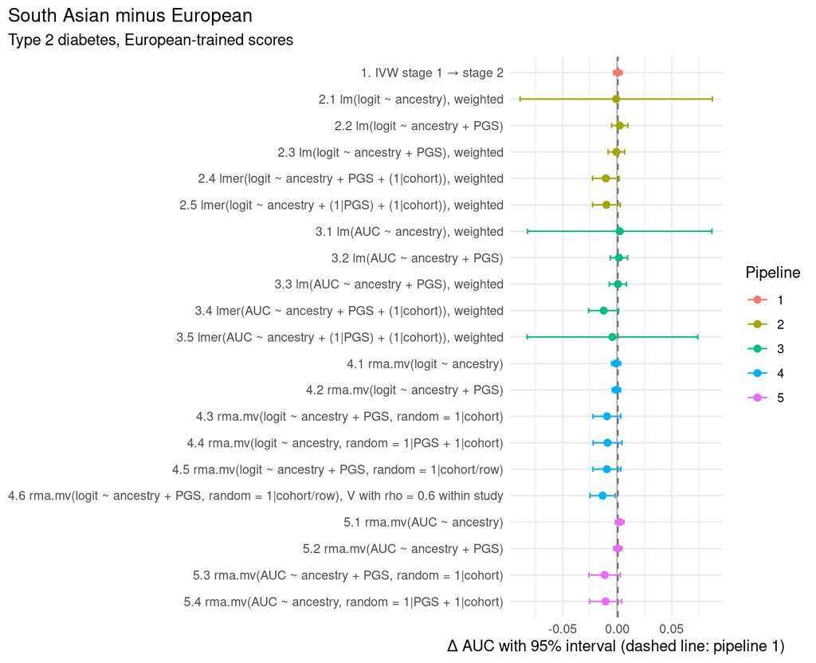

```r
# xlim_from: a function of the model names that picks the models whose intervals
# set the x-axis. Intervals of the other models are cut at the edges, and the
# caption names them.
plot_all <- function(comparison, xlim_from = NULL) {
  d <- est_tbl %>%
    filter(.data$comparison == .env$comparison) %>%
    mutate(model = factor(.data$model, levels = rev(.data$model)))
  ref <- d$delta_auc[d$pipeline == "1"]
  xlim <- NULL
  caption <- NULL
  if (!is.null(xlim_from)) {
    keep <- xlim_from(as.character(d$model))
    xlim <- range(c(d$lo_auc[keep], d$hi_auc[keep], 0))
    cut <- as.character(d$model[d$lo_auc < xlim[1] | d$hi_auc > xlim[2]])
    if (length(cut)) {
      caption <- paste0(
        "Intervals cut at the axis edges:\n",
        paste0(cut, " (", fmt(d$lo_auc[d$model %in% cut]), " to ", fmt(d$hi_auc[d$model %in% cut]), ")", collapse = "\n")
      )
    }
  }
  ggplot(d, aes(x = delta_auc, y = model, colour = pipeline)) +
    geom_vline(xintercept = 0, colour = "grey70") +
    geom_vline(xintercept = ref, linetype = "dashed", colour = "grey40") +
    geom_errorbar(aes(xmin = lo_auc, xmax = hi_auc), width = 0.2, orientation = "y") +
    geom_point(size = 2) +
    coord_cartesian(xlim = xlim) +
    labs(
      x = "Δ AUC with 95% interval (dashed line: pipeline 1)", y = NULL, colour = "Pipeline",
      title = paste(comparison, "minus European"),
      subtitle = "Type 2 diabetes, European-trained scores",
      caption = caption
    ) +
    theme_minimal(base_size = 11) +
    theme(plot.title.position = "plot", plot.caption = element_text(hjust = 0), plot.caption.position = "plot")
}
plot_all("South Asian")
```

**What I take from the South Asian comparison.**

- Without a sample-set term, the models with a term for the score give between -0.0006 and 0.0024. Pipeline 1 gives 0.0007.
- With a sample-set term, the estimates are between -0.013 and -0.004.
- 11 of the 13 scores were measured in one European and one South Asian sample set.
- The logit-scale and AUC-scale versions of each model give estimates within about 0.003 of each other, except 2.5 and 3.5 (-0.0098 against -0.0043).
- Four pairs differ in sign, all with both values close to 0: 2.1 and 3.1 (-0.0009 against 0.0024), 2.3 and 3.3 (-0.0006 against 0.0007), 4.1 and 5.1 (-0.0009 against 0.0024), and 4.2 and 5.2 (-0.0006 against 0.0007).
- For 3.5, `lmer` and `rma.mv` report different variance components for the same terms (5.4).
- `rma.mv(AUC ~ ancestry + PGS)` (5.2) gives almost the same estimate and SE as pipeline 1.
- `lm` and `rma.mv` give the same estimates for the same fixed terms. Their SEs differ by the factor σ.
- `lmer` and `rma.mv` do not give the same estimates:

```r
show_pairs("South Asian")
```

| Model pair | lmer Δ AUC | rma.mv Δ AUC |
| --- | --- | --- |
| 2.4 lmer(logit ~ ancestry + PGS + (1\|cohort)), weighted vs 4.3 rma.mv(logit ~ ancestry + PGS, random = 1\|cohort) | -0.0103 | -0.0094 |
| 2.5 lmer(logit ~ ancestry + (1\|PGS) + (1\|cohort)), weighted vs 4.4 rma.mv(logit ~ ancestry, random = 1\|PGS + 1\|cohort) | -0.0098 | -0.0088 |
| 3.4 lmer(AUC ~ ancestry + PGS + (1\|cohort)), weighted vs 5.3 rma.mv(AUC ~ ancestry + PGS, random = 1\|cohort) | -0.0123 | -0.0114 |
| 3.5 lmer(AUC ~ ancestry + (1\|PGS) + (1\|cohort)), weighted vs 5.4 rma.mv(AUC ~ ancestry, random = 1\|PGS + 1\|cohort) | -0.0043 | -0.0105 |

- The metafor docs say that `lme()` and `lmer()` “lead to a mix of additive and multiplicative variance components, which is not how multivariate/multilevel meta-analytic models are typically defined” ([metafor: rma() vs lm(), lme(), lmer()](https://www.metafor-project.org/doku.php/tips:rma_vs_lm_lme_lmer)). In the example on that page the `lme` estimate also differs from the `rma` one.

# Hispanic or Latin American versus European

I go through the same steps, more briefly. I think most of the reasoning carries over, so I only point out what is different.

## The master table

```r
kable(hi %>% select(-PGS, -cohort), digits = 4)
```

| pgs_id | ancestry | sampleset_id | study | n_individuals | covariate_class | auc | ci_lower | ci_upper | logit_auc | se_logit | se_auc |
| --- | --- | --- | --- | --- | --- | --- | --- | --- | --- | --- | --- |
| PGS000330 | European | PSS011737 | All of Us | 109021 | Age/sex/PCs/technical | 0.726 | 0.721 | 0.730 | 0.9744 | 0.0115 | 0.0023 |
| PGS000713 | European | PSS011737 | All of Us | 109021 | Age/sex/PCs/technical | 0.712 | 0.707 | 0.717 | 0.9051 | 0.0124 | 0.0026 |
| PGS000729 | European | PSS011737 | All of Us | 109021 | Age/sex/PCs/technical | 0.712 | 0.707 | 0.717 | 0.9051 | 0.0124 | 0.0026 |
| PGS000805 | European | PSS011737 | All of Us | 109021 | Age/sex/PCs/technical | 0.707 | 0.702 | 0.712 | 0.8809 | 0.0123 | 0.0026 |
| PGS000864 | European | PSS011737 | All of Us | 109021 | Age/sex/PCs/technical | 0.687 | 0.682 | 0.692 | 0.7861 | 0.0119 | 0.0026 |
| PGS000868 | European | PSS011737 | All of Us | 109021 | Age/sex/PCs/technical | 0.696 | 0.691 | 0.701 | 0.8283 | 0.0121 | 0.0026 |
| PGS001818 | European | PSS011737 | All of Us | 109021 | Age/sex/PCs/technical | 0.709 | 0.704 | 0.714 | 0.8905 | 0.0124 | 0.0026 |
| PGS002026 | European | PSS011737 | All of Us | 109021 | Age/sex/PCs/technical | 0.714 | 0.709 | 0.719 | 0.9149 | 0.0125 | 0.0026 |
| PGS002671 | European | PSS011737 | All of Us | 109021 | Age/sex/PCs/technical | 0.704 | 0.699 | 0.708 | 0.8664 | 0.0110 | 0.0023 |
| PGS002771 | European | PSS011737 | All of Us | 109021 | Age/sex/PCs/technical | 0.735 | 0.730 | 0.740 | 1.0201 | 0.0131 | 0.0026 |
| PGS002780 | European | PSS011737 | All of Us | 109021 | Age/sex/PCs/technical | 0.694 | 0.689 | 0.699 | 0.8189 | 0.0120 | 0.0026 |
| PGS000330 | Hispanic or Latin American | PSS011736 | All of Us | 33652 | Age/sex/PCs/technical | 0.768 | 0.761 | 0.775 | 1.1971 | 0.0200 | 0.0036 |
| PGS000713 | Hispanic or Latin American | PSS011736 | All of Us | 33652 | Age/sex/PCs/technical | 0.762 | 0.755 | 0.769 | 1.1637 | 0.0197 | 0.0036 |
| PGS000729 | Hispanic or Latin American | PSS011736 | All of Us | 33652 | Age/sex/PCs/technical | 0.761 | 0.754 | 0.768 | 1.1582 | 0.0196 | 0.0036 |
| PGS000805 | Hispanic or Latin American | PSS011736 | All of Us | 33652 | Age/sex/PCs/technical | 0.764 | 0.758 | 0.771 | 1.1747 | 0.0184 | 0.0033 |
| PGS000864 | Hispanic or Latin American | PSS011736 | All of Us | 33652 | Age/sex/PCs/technical | 0.745 | 0.738 | 0.752 | 1.0721 | 0.0188 | 0.0036 |
| PGS000868 | Hispanic or Latin American | PSS011736 | All of Us | 33652 | Age/sex/PCs/technical | 0.758 | 0.751 | 0.765 | 1.1417 | 0.0195 | 0.0036 |
| PGS001818 | Hispanic or Latin American | PSS011736 | All of Us | 33652 | Age/sex/PCs/technical | 0.762 | 0.755 | 0.769 | 1.1637 | 0.0197 | 0.0036 |
| PGS002026 | Hispanic or Latin American | PSS011736 | All of Us | 33652 | Age/sex/PCs/technical | 0.764 | 0.757 | 0.771 | 1.1747 | 0.0198 | 0.0036 |
| PGS002671 | Hispanic or Latin American | PSS011736 | All of Us | 33652 | Age/sex/PCs/technical | 0.761 | 0.754 | 0.768 | 1.1582 | 0.0196 | 0.0036 |
| PGS002771 | Hispanic or Latin American | PSS011736 | All of Us | 33652 | Age/sex/PCs/technical | 0.775 | 0.769 | 0.782 | 1.2368 | 0.0191 | 0.0033 |
| PGS002780 | Hispanic or Latin American | PSS011736 | All of Us | 33652 | Age/sex/PCs/technical | 0.756 | 0.749 | 0.763 | 1.1309 | 0.0194 | 0.0036 |

22 rows: 11 scores in 2 sample sets.

```r
hi_layout <- hi %>%
  mutate(column = paste0(ancestry, " · ", sampleset_id, " (", study, ")")) %>%
  count(pgs_id, column) %>%
  pivot_wider(names_from = column, values_from = n, values_fill = 0)
kable(hi_layout)
```

| pgs_id | European · PSS011737 (All of Us) | Hispanic or Latin American · PSS011736 (All of Us) |
| --- | --- | --- |
| PGS000330 | 1 | 1 |
| PGS000713 | 1 | 1 |
| PGS000729 | 1 | 1 |
| PGS000805 | 1 | 1 |
| PGS000864 | 1 | 1 |
| PGS000868 | 1 | 1 |
| PGS001818 | 1 | 1 |
| PGS002026 | 1 | 1 |
| PGS002671 | 1 | 1 |
| PGS002771 | 1 | 1 |
| PGS002780 | 1 | 1 |

```r
hi_sets <- hi %>% distinct(ancestry, sampleset_id, study)
```

- To me this is the key difference from the South Asian comparison.
- There are only 2 sample sets, one per ancestry group. Every European row comes from PSS011737 and every Hispanic or Latin American row from PSS011736.
- So ancestry and sample set are not just hard to separate here: as far as I can see, they are **the same variable**.
- I keep this in mind for the models with `(1 | cohort)`.

## Pipeline 1: IVW in two stages (the analysis)

```r
hi_s1 <- hi %>%
  group_by(pgs_id, ancestry) %>%
  summarise(pooled = list(ivw_pool_logit(logit_auc, se_logit)), .groups = "drop") %>%
  unnest_wider(pooled) %>%
  mutate(auc = plogis(eta), se_auc = se * auc * (1 - auc))
hi_diff <- hi_s1 %>%
  select(pgs_id, ancestry, auc, se_auc) %>%
  pivot_wider(names_from = ancestry, values_from = c(auc, se_auc)) %>%
  transmute(
    pgs_id,
    auc_european = `auc_European`, auc_hispanic = `auc_Hispanic or Latin American`,
    delta = auc_hispanic - auc_european,
    se_delta = sqrt(`se_auc_European`^2 + `se_auc_Hispanic or Latin American`^2),
    weight = 1 / se_delta^2
  )
kable(hi_diff, digits = 5)
```

| pgs_id | auc_european | auc_hispanic | delta | se_delta | weight |
| --- | --- | --- | --- | --- | --- |
| PGS000330 | 0.726 | 0.768 | 0.042 | 0.00425 | 55490 |
| PGS000713 | 0.712 | 0.762 | 0.050 | 0.00439 | 51895 |
| PGS000729 | 0.712 | 0.761 | 0.049 | 0.00439 | 51895 |
| PGS000805 | 0.707 | 0.764 | 0.057 | 0.00419 | 57001 |
| PGS000864 | 0.687 | 0.745 | 0.058 | 0.00439 | 51898 |
| PGS000868 | 0.696 | 0.758 | 0.062 | 0.00439 | 51896 |
| PGS001818 | 0.709 | 0.762 | 0.053 | 0.00439 | 51895 |
| PGS002026 | 0.714 | 0.764 | 0.050 | 0.00439 | 51895 |
| PGS002671 | 0.704 | 0.761 | 0.057 | 0.00425 | 55487 |
| PGS002771 | 0.735 | 0.775 | 0.040 | 0.00419 | 56991 |
| PGS002780 | 0.694 | 0.756 | 0.062 | 0.00439 | 51896 |

```r
hi_p1 <- with(hi_diff, c(delta_auc = sum(weight * delta) / sum(weight), se = sqrt(1 / sum(weight))))
hi_p1
```

```
delta_auc        se
0.0526147 0.0013038
```

```r
hi_p1_saved <- saved_stage2("Hispanic or Latin American")
record("Hispanic or Latin American", "1", "1. IVW stage 1 → stage 2", "AUC", est = hi_p1[["delta_auc"]], se = hi_p1[["se"]])
c(saved_delta_auc = hi_p1_saved$delta_hat, saved_se = hi_p1_saved$se_hat)
```

```
saved_delta_auc        saved_se
      0.0526147       0.0013038
```

- I get Δ AUC = 0.0526 (SE 0.0013), the same as the saved stage-2 table.
- Here the scores seem to do better in Hispanic or Latin American participants than in European participants.
- The same comparison of fixed and random effects as in the South Asian pipeline 1:

```r
hi_p1_re <- map_dfr(c("FE", "REML", "DL"), function(m) {
  f <- rma(hi_diff$delta, sei = hi_diff$se_delta, method = m)
  tibble(method = m, `Δ AUC` = coef(f)[[1]], SE = f$se, `95% CI` = paste0(fmt(f$ci.lb), " to ", fmt(f$ci.ub)), tau = sqrt(f$tau2))
})
kable(hi_p1_re, digits = 4)
```

| method | Δ AUC | SE | 95% CI | tau |
| --- | --- | --- | --- | --- |
| FE | 0.0526 | 0.0013 | 0.0501 to 0.0552 | 0.000 |
| REML | 0.0527 | 0.0022 | 0.0483 to 0.0571 | 0.006 |
| DL | 0.0527 | 0.0022 | 0.0483 to 0.0571 | 0.006 |

## Pipeline 2: logit scale, `lm` then `lmer`

```r
fit_hi_2_1 <- lm(logit_auc ~ ancestry, data = hi, weights = 1 / se_logit^2)
fit_hi_2_2 <- lm(logit_auc ~ ancestry + PGS, data = hi)
fit_hi_2_3 <- lm(logit_auc ~ ancestry + PGS, data = hi, weights = 1 / se_logit^2)
fit_hi_2_4 <- lmer(logit_auc ~ ancestry + PGS + (1 | cohort), data = hi, weights = 1 / se_logit^2)
fit_hi_2_5 <- lmer(logit_auc ~ ancestry + (1 | PGS) + (1 | cohort), data = hi, weights = 1 / se_logit^2)
```

### 2.1 Ancestry only

```r
summary(fit_hi_2_1)
```

```
Call:
lm(formula = logit_auc ~ ancestry, data = hi, weights = 1/se_logit^2)

Weighted Residuals:
   Min     1Q Median     3Q    Max
-8.577 -1.397  0.152  1.384 10.096

Coefficients:
                                   Estimate Std. Error t value     Pr(>|t|)
(Intercept)                          0.8879     0.0152   58.30      < 2e-16 ***
ancestryHispanic or Latin American   0.2728     0.0288    9.48 0.0000000077 ***
---
Signif. codes:  0 '***' 0.001 '**' 0.01 '*' 0.05 '.' 0.1 ' ' 1

Residual standard error: 4.17 on 20 degrees of freedom
Multiple R-squared:  0.818, Adjusted R-squared:  0.809
F-statistic: 89.9 on 1 and 20 DF,  p-value: 0.00000000766
```

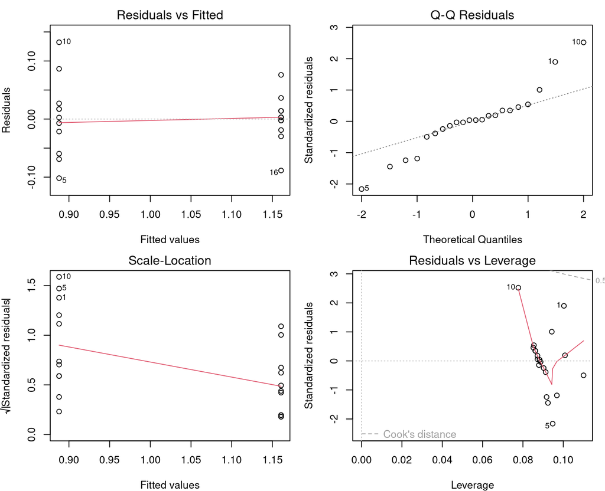

```r
diag_lm(fit_hi_2_1)
```

### 2.2 Add the score, no weights

```r
summary(fit_hi_2_2)
```

```
Call:
lm(formula = logit_auc ~ ancestry + PGS, data = hi)

Residuals:
    Min      1Q  Median      3Q     Max
-0.0272 -0.0100  0.0000  0.0100  0.0272

Coefficients:
                                   Estimate Std. Error t value Pr(>|t|)
(Intercept)                          0.9502     0.0170   55.99  8.0e-14 ***
ancestryHispanic or Latin American   0.2710     0.0098   27.66  8.9e-11 ***
PGSPGS000713                        -0.0513     0.0230   -2.23   0.0495 *
PGSPGS000729                        -0.0541     0.0230   -2.35   0.0404 *
PGSPGS000805                        -0.0579     0.0230   -2.52   0.0303 *
PGSPGS000864                        -0.1566     0.0230   -6.82  4.7e-05 ***
PGSPGS000868                        -0.1007     0.0230   -4.38   0.0014 **
PGSPGS001818                        -0.0586     0.0230   -2.55   0.0288 *
PGSPGS002026                        -0.0409     0.0230   -1.78   0.1053
PGSPGS002671                        -0.0734     0.0230   -3.20   0.0096 **
PGSPGS002771                         0.0427     0.0230    1.86   0.0927 .
PGSPGS002780                        -0.1109     0.0230   -4.82   0.0007 ***
---
Signif. codes:  0 '***' 0.001 '**' 0.01 '*' 0.05 '.' 0.1 ' ' 1

Residual standard error: 0.023 on 10 degrees of freedom
Multiple R-squared:  0.989, Adjusted R-squared:  0.976
F-statistic: 79.3 on 11 and 10 DF,  p-value: 0.0000000323
```

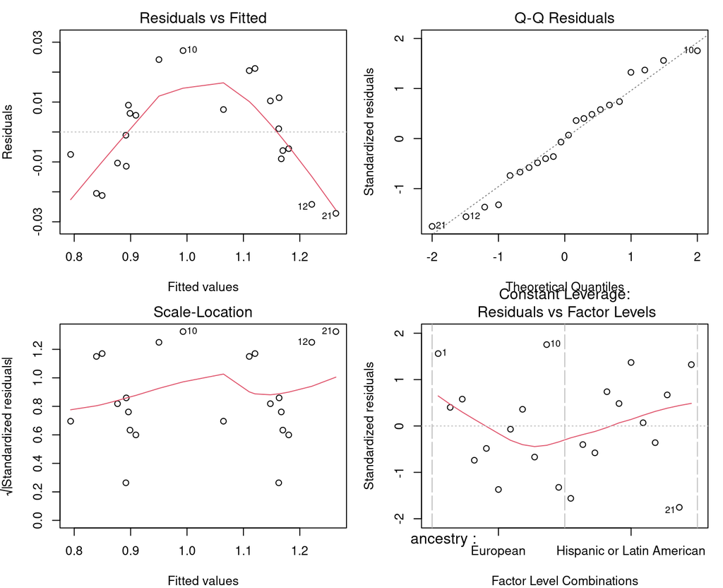

```r
diag_lm(fit_hi_2_2)
```

### 2.3 Add the score, with weights

```r
summary(fit_hi_2_3)
```

```
Call:
lm(formula = logit_auc ~ ancestry + PGS, data = hi, weights = 1/se_logit^2)

Weighted Residuals:
    Min      1Q  Median      3Q     Max
-1.9602 -0.5371  0.0103  0.7217  1.5518

Coefficients:
                                   Estimate Std. Error t value Pr(>|t|)
(Intercept)                         0.96225    0.01436   67.01  1.3e-14 ***
ancestryHispanic or Latin American  0.27162    0.00978   27.78  8.5e-11 ***
PGSPGS000713                       -0.06086    0.02055   -2.96  0.01425 *
PGSPGS000729                       -0.06245    0.02054   -3.04  0.01246 *
PGSPGS000805                       -0.07452    0.02027   -3.68  0.00427 **
PGSPGS000864                       -0.17202    0.02006   -8.58  6.4e-06 ***
PGSPGS000868                       -0.12234    0.02027   -6.03  0.00013 ***
PGSPGS001818                       -0.07128    0.02050   -3.48  0.00595 **
PGSPGS002026                       -0.05071    0.02060   -2.46  0.03358 *
PGSPGS002671                       -0.09102    0.01963   -4.64  0.00093 ***
PGSPGS002771                        0.04024    0.02084    1.93  0.08232 .
PGSPGS002780                       -0.13214    0.02023   -6.53  6.6e-05 ***
---
Signif. codes:  0 '***' 0.001 '**' 0.01 '*' 0.05 '.' 0.1 ' ' 1

Residual standard error: 1.42 on 10 degrees of freedom
Multiple R-squared:  0.99,  Adjusted R-squared:  0.978
F-statistic: 85.8 on 11 and 10 DF,  p-value: 0.000000022
```

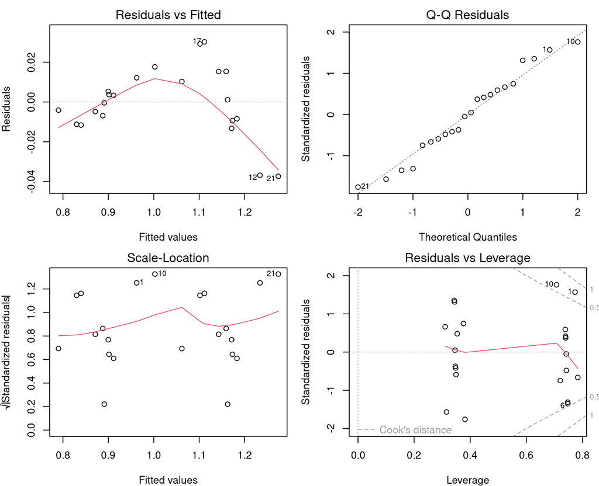

```r
diag_lm(fit_hi_2_3)
```

### 2.4 Add a random effect for the sample set

```r
summary(fit_hi_2_4)
```

```
Linear mixed model fit by REML ['lmerMod']
Formula: logit_auc ~ ancestry + PGS + (1 | cohort)
   Data: hi
Weights: 1/se_logit^2

REML criterion at convergence: -37.8

Scaled residuals:
    Min      1Q  Median      3Q     Max
-1.3843 -0.3793  0.0073  0.5097  1.0959

Random effects:
 Groups   Name        Variance Std.Dev.
 cohort   (Intercept) 36       6.00
 Residual              2       1.42
Number of obs: 22, groups:  cohort, 2

Fixed effects:
                                   Estimate Std. Error t value
(Intercept)                          0.9622     6.0014    0.16
ancestryHispanic or Latin American   0.2716     8.4873    0.03
PGSPGS000713                        -0.0609     0.0205   -2.96
PGSPGS000729                        -0.0624     0.0205   -3.04
PGSPGS000805                        -0.0745     0.0203   -3.68
PGSPGS000864                        -0.1720     0.0201   -8.58
PGSPGS000868                        -0.1223     0.0203   -6.03
PGSPGS001818                        -0.0713     0.0205   -3.48
PGSPGS002026                        -0.0507     0.0206   -2.46
PGSPGS002671                        -0.0910     0.0196   -4.64
PGSPGS002771                         0.0402     0.0208    1.93
PGSPGS002780                        -0.1321     0.0202   -6.53

Correlation of Fixed Effects:
             (Intr) anHoLA PGSPGS00071 PGSPGS00072 PGSPGS00080 PGSPGS000864 PGSPGS000868 PGSPGS001 PGSPGS0020
ancstryHoLA  -0.707
PGSPGS00071  -0.002  0.000
PGSPGS00072  -0.002  0.000  0.475
PGSPGS00080  -0.002  0.000  0.481       0.482
PGSPGS000864 -0.002  0.000  0.486       0.486       0.493
PGSPGS000868 -0.002  0.000  0.481       0.481       0.488       0.493
PGSPGS00181  -0.002  0.000  0.476       0.476       0.482       0.487        0.482
PGSPGS00202  -0.002  0.000  0.473       0.474       0.480       0.485        0.480        0.475
PGSPGS00267  -0.002  0.000  0.497       0.497       0.503       0.509        0.503        0.498     0.495
PGSPGS00277  -0.002  0.000  0.468       0.468       0.475       0.480        0.474        0.469     0.467
PGSPGS00278  -0.002  0.000  0.482       0.482       0.489       0.494        0.488        0.483     0.481
             PGSPGS0026 PGSPGS00277
ancstryHoLA
PGSPGS00071
PGSPGS00072
PGSPGS00080
PGSPGS000864
PGSPGS000868
PGSPGS00181
PGSPGS00202
PGSPGS00267
PGSPGS00277   0.489
PGSPGS00278   0.504      0.475
```

```r
ranef(fit_hi_2_4)
```

```
$cohort
          (Intercept)
PSS011736 -1.9245e-10
PSS011737  7.1506e-12

with conditional variances for "cohort"
```

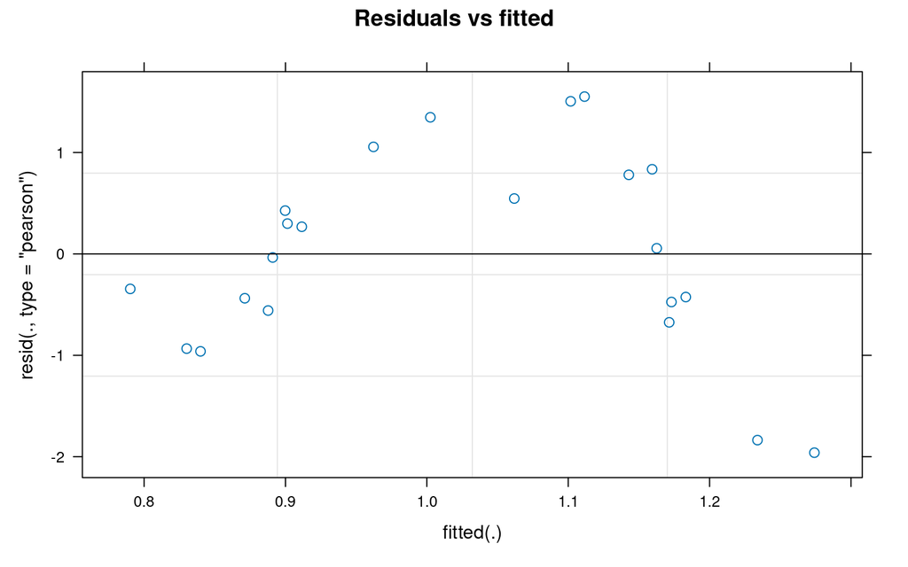

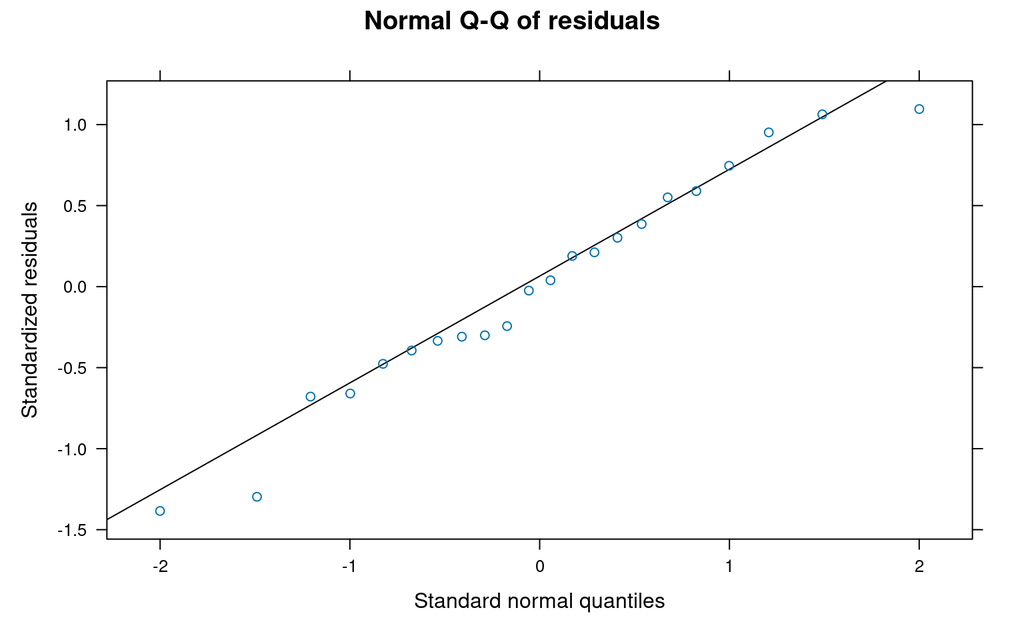

```r
diag_lmer(fit_hi_2_4)
```

**What we see.**

- The estimate barely moves, but its SE grows to 8.49 on the logit scale.
- In this comparison there is one sample set per ancestry group.
- The metafor docs say what a flat profile means for this model (4.3).

### 2.5 Score as a random effect too

```r
summary(fit_hi_2_5)
```

```
Linear mixed model fit by REML ['lmerMod']
Formula: logit_auc ~ ancestry + (1 | PGS) + (1 | cohort)
   Data: hi
Weights: 1/se_logit^2

REML criterion at convergence: -63.6

Scaled residuals:
    Min      1Q  Median      3Q     Max
-1.1515 -0.4414  0.0106  0.4696  1.3572

Random effects:
 Groups   Name        Variance Std.Dev.
 PGS      (Intercept)  0.00328 0.0573
 cohort   (Intercept) 31.69560 5.6299
 Residual              2.00600 1.4163
Number of obs: 22, groups:  PGS, 11; cohort, 2

Fixed effects:
                                   Estimate Std. Error t value
(Intercept)                           0.890      5.630    0.16
ancestryHispanic or Latin American    0.272      7.962    0.03

Correlation of Fixed Effects:
            (Intr)
ancstryHoLA -0.707
optimizer (nloptwrap) convergence code: 0 (OK)
unable to evaluate scaled gradient
Model failed to converge: degenerate  Hessian with 1 negative eigenvalues
  See ?lme4::convergence and ?lme4::troubleshooting.
```

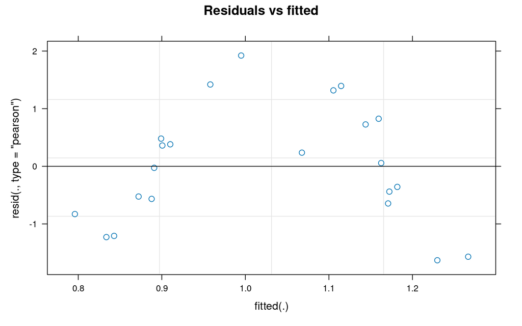

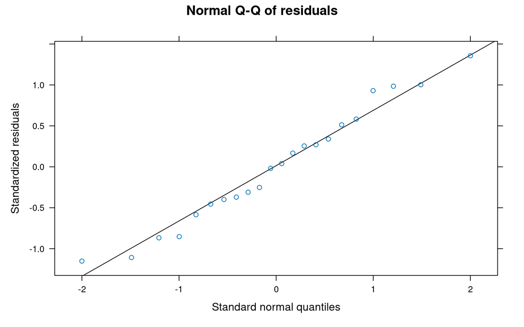

```r
diag_lmer(fit_hi_2_5)
```

### Pipeline 2 so far

```r
show_rows(hc, est_tbl %>% filter(comparison == hc, pipeline %in% c("1", "2")) %>% pull(model))
```

| model | scale | estimate (model scale) | SE (model scale) | σ | Δ AUC | SE (AUC) | 95% CI | note |
| --- | --- | --- | --- | --- | --- | --- | --- | --- |
| 1. IVW stage 1 → stage 2 | AUC | 0.05261 | 0.00130 | NA | 0.05261 | 0.00130 | 0.0501 to 0.0552 |  |
| 2.1 lm(logit ~ ancestry), weighted | logit | 0.27278 | 0.02876 | 4.17022 | 0.05300 | 0.00544 | 0.0423 to 0.0637 |  |
| 2.2 lm(logit ~ ancestry + PGS) | logit | 0.27099 | 0.00980 | 0.02298 | 0.05261 | 0.00190 | 0.0489 to 0.0563 |  |
| 2.3 lm(logit ~ ancestry + PGS), weighted | logit | 0.27162 | 0.00978 | 1.41594 | 0.05273 | 0.00185 | 0.0491 to 0.0563 |  |
| 2.4 lmer(logit ~ ancestry + PGS + (1\|cohort)), weighted | logit | 0.27162 | 8.48726 | 1.41594 | 0.05273 | 1.64926 | -3.1798 to 3.2853 |  |
| 2.5 lmer(logit ~ ancestry + (1\|PGS) + (1\|cohort)), weighted | logit | 0.27170 | 7.96186 | 1.41633 | 0.05276 | 1.54764 | -2.9806 to 3.0861 | convergence warning |

## Pipeline 3: AUC scale, `lm` then `lmer`

```r
fit_hi_3_1 <- lm(auc ~ ancestry, data = hi, weights = 1 / se_auc^2)
fit_hi_3_2 <- lm(auc ~ ancestry + PGS, data = hi)
fit_hi_3_3 <- lm(auc ~ ancestry + PGS, data = hi, weights = 1 / se_auc^2)
fit_hi_3_4 <- lmer(auc ~ ancestry + PGS + (1 | cohort), data = hi, weights = 1 / se_auc^2)
fit_hi_3_5 <- lmer(auc ~ ancestry + (1 | PGS) + (1 | cohort), data = hi, weights = 1 / se_auc^2)
```

### 3.1 Ancestry only

```r
summary(fit_hi_3_1)
```

```
Call:
lm(formula = auc ~ ancestry, data = hi, weights = 1/se_auc^2)

Weighted Residuals:
   Min     1Q Median     3Q    Max
-8.618 -1.449  0.048  1.181 10.196

Coefficients:
                                   Estimate Std. Error t value     Pr(>|t|)
(Intercept)                         0.70899    0.00316  224.62      < 2e-16 ***
ancestryHispanic or Latin American  0.05269    0.00546    9.66 0.0000000057 ***
---
Signif. codes:  0 '***' 0.001 '**' 0.01 '*' 0.05 '.' 0.1 ' ' 1

Residual standard error: 4.19 on 20 degrees of freedom
Multiple R-squared:  0.823, Adjusted R-squared:  0.815
F-statistic: 93.2 on 1 and 20 DF,  p-value: 0.00000000568
```

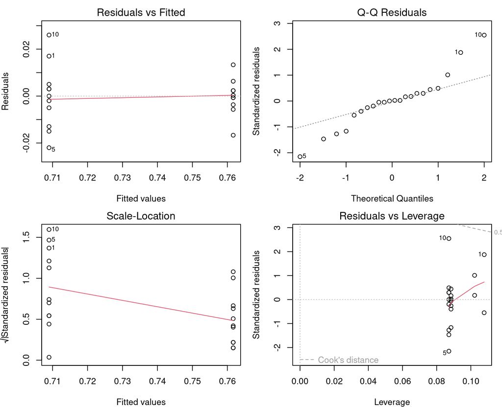

```r
diag_lm(fit_hi_3_1)
```

### 3.2 Add the score, no weights

```r
summary(fit_hi_3_2)
```

```
Call:
lm(formula = auc ~ ancestry + PGS, data = hi)

Residuals:
     Min       1Q   Median       3Q      Max
-0.00636 -0.00214  0.00000  0.00214  0.00636

Coefficients:
                                   Estimate Std. Error t value Pr(>|t|)
(Intercept)                         0.72064    0.00385  187.40  < 2e-16 ***
ancestryHispanic or Latin American  0.05273    0.00222   23.75    4e-10 ***
PGSPGS000713                       -0.01000    0.00521   -1.92  0.08372 .
PGSPGS000729                       -0.01050    0.00521   -2.02  0.07138 .
PGSPGS000805                       -0.01150    0.00521   -2.21  0.05167 .
PGSPGS000864                       -0.03100    0.00521   -5.95  0.00014 ***
PGSPGS000868                       -0.02000    0.00521   -3.84  0.00326 **
PGSPGS001818                       -0.01150    0.00521   -2.21  0.05167 .
PGSPGS002026                       -0.00800    0.00521   -1.54  0.15543
PGSPGS002671                       -0.01450    0.00521   -2.78  0.01929 *
PGSPGS002771                        0.00800    0.00521    1.54  0.15543
PGSPGS002780                       -0.02200    0.00521   -4.23  0.00176 **
---
Signif. codes:  0 '***' 0.001 '**' 0.01 '*' 0.05 '.' 0.1 ' ' 1

Residual standard error: 0.00521 on 10 degrees of freedom
Multiple R-squared:  0.985, Adjusted R-squared:  0.968
F-statistic: 58.6 on 11 and 10 DF,  p-value: 0.000000141
```

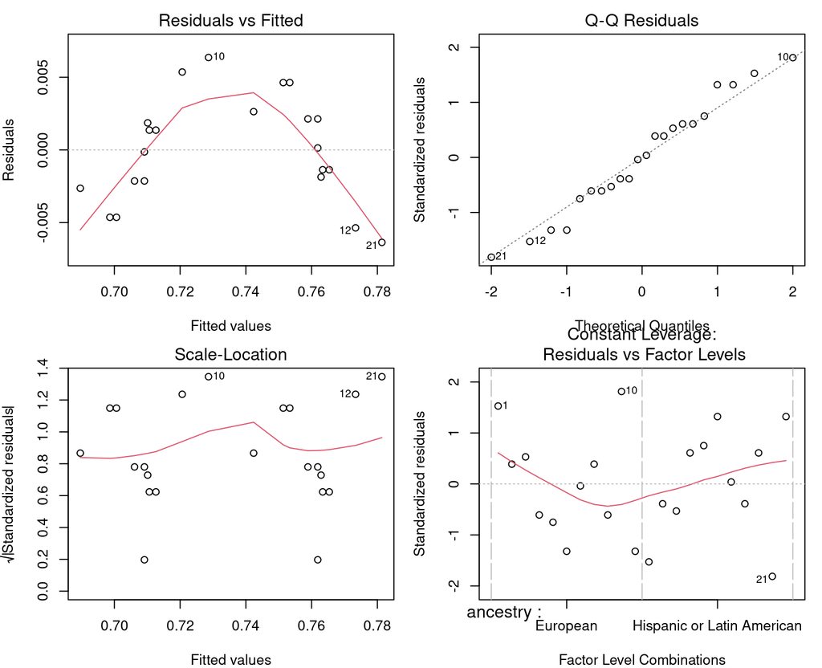

```r
diag_lm(fit_hi_3_2)
```

### 3.3 Add the score, with weights

```r
summary(fit_hi_3_3)
```

```
Call:
lm(formula = auc ~ ancestry + PGS, data = hi, weights = 1/se_auc^2)

Weighted Residuals:
    Min      1Q  Median      3Q     Max
-2.3885 -0.6620  0.0102  0.8595  1.8342

Coefficients:
                                   Estimate Std. Error t value      Pr(>|t|)
(Intercept)                         0.72290    0.00338  213.86       < 2e-16 ***
ancestryHispanic or Latin American  0.05261    0.00224   23.48 0.00000000044 ***
PGSPGS000713                       -0.01178    0.00487   -2.42       0.03613 *
PGSPGS000729                       -0.01212    0.00487   -2.49       0.03208 *
PGSPGS000805                       -0.01427    0.00481   -2.97       0.01407 *
PGSPGS000864                       -0.03408    0.00487   -7.00 0.00003734449 ***
PGSPGS000868                       -0.02373    0.00487   -4.87       0.00065 ***
PGSPGS001818                       -0.01377    0.00487   -2.83       0.01795 *
PGSPGS002026                       -0.00978    0.00487   -2.01       0.07236 .
PGSPGS002671                       -0.01762    0.00469   -3.76       0.00374 **
PGSPGS002771                        0.00742    0.00481    1.54       0.15388
PGSPGS002780                       -0.02573    0.00487   -5.28       0.00036 ***
---
Signif. codes:  0 '***' 0.001 '**' 0.01 '*' 0.05 '.' 0.1 ' ' 1

Residual standard error: 1.72 on 10 degrees of freedom
Multiple R-squared:  0.985, Adjusted R-squared:  0.969
F-statistic: 60.3 on 11 and 10 DF,  p-value: 0.000000123
```

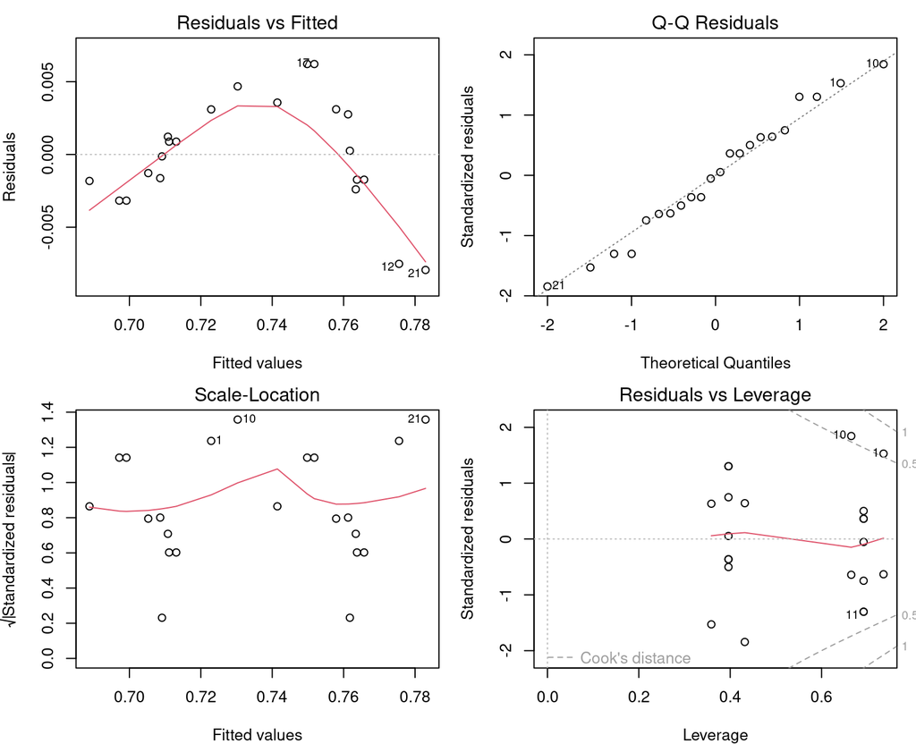

```r
diag_lm(fit_hi_3_3)
```

### 3.4 Add a random effect for the sample set

```r
summary(fit_hi_3_4)
```

```
Linear mixed model fit by REML ['lmerMod']
Formula: auc ~ ancestry + PGS + (1 | cohort)
   Data: hi
Weights: 1/se_auc^2

REML criterion at convergence: -67.3

Scaled residuals:
    Min      1Q  Median      3Q     Max
-1.3900 -0.3853  0.0059  0.5002  1.0674

Random effects:
 Groups   Name        Variance Std.Dev.
 cohort   (Intercept) 601.09   24.52
 Residual               2.95    1.72
Number of obs: 22, groups:  cohort, 2

Fixed effects:
                                   Estimate Std. Error t value
(Intercept)                         0.72290   24.51707    0.03
ancestryHispanic or Latin American  0.05261   34.67237    0.00
PGSPGS000713                       -0.01178    0.00487   -2.42
PGSPGS000729                       -0.01212    0.00487   -2.49
PGSPGS000805                       -0.01427    0.00481   -2.97
PGSPGS000864                       -0.03408    0.00487   -7.00
PGSPGS000868                       -0.02373    0.00487   -4.87
PGSPGS001818                       -0.01377    0.00487   -2.83
PGSPGS002026                       -0.00978    0.00487   -2.01
PGSPGS002671                       -0.01762    0.00469   -3.76
PGSPGS002771                        0.00742    0.00481    1.54
PGSPGS002780                       -0.02573    0.00487   -5.28

Correlation of Fixed Effects:
             (Intr) anHoLA PGSPGS00071 PGSPGS00072 PGSPGS00080 PGSPGS000864 PGSPGS000868 PGSPGS001 PGSPGS0020
ancstryHoLA  -0.707
PGSPGS00071   0.000  0.000
PGSPGS00072   0.000  0.000  0.464
PGSPGS00080   0.000  0.000  0.470       0.470
PGSPGS000864  0.000  0.000  0.464       0.464       0.470
PGSPGS000868  0.000  0.000  0.464       0.464       0.470       0.464
PGSPGS00181   0.000  0.000  0.464       0.464       0.470       0.464        0.464
PGSPGS00202   0.000  0.000  0.464       0.464       0.470       0.464        0.464        0.464
PGSPGS00267   0.000  0.000  0.481       0.481       0.488       0.481        0.481        0.481     0.481
PGSPGS00277   0.000  0.000  0.470       0.470       0.477       0.470        0.470        0.470     0.470
PGSPGS00278   0.000  0.000  0.464       0.464       0.470       0.464        0.464        0.464     0.464
             PGSPGS0026 PGSPGS00277
ancstryHoLA
PGSPGS00071
PGSPGS00072
PGSPGS00080
PGSPGS000864
PGSPGS000868
PGSPGS00181
PGSPGS00202
PGSPGS00267
PGSPGS00277   0.488
PGSPGS00278   0.481      0.470
```

```r
ranef(fit_hi_3_4)
```

```
$cohort
              (Intercept)
PSS011736 -0.000000050389
PSS011737 -0.000000056771

with conditional variances for "cohort"
```

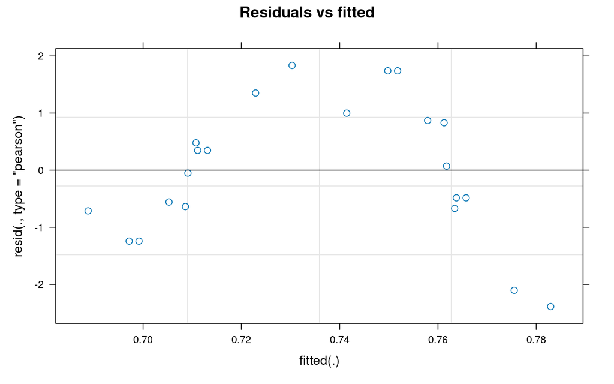

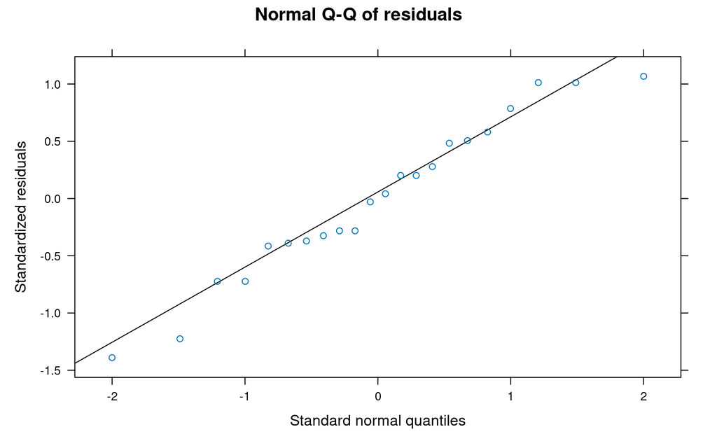

```r
diag_lmer(fit_hi_3_4)
```

### 3.5 Score as a random effect too

```r
summary(fit_hi_3_5)
```

```
Linear mixed model fit by REML ['lmerMod']
Formula: auc ~ ancestry + (1 | PGS) + (1 | cohort)
   Data: hi
Weights: 1/se_auc^2

REML criterion at convergence: -125.7

Scaled residuals:
    Min      1Q  Median      3Q     Max
-1.0456 -0.3922  0.0122  0.4231  1.5153

Random effects:
 Groups   Name        Variance   Std.Dev.
 PGS      (Intercept)   0.000121  0.011
 cohort   (Intercept) 374.550064 19.353
 Residual               2.957548  1.720
Number of obs: 22, groups:  PGS, 11; cohort, 2

Fixed effects:
                                   Estimate Std. Error t value
(Intercept)                          0.7088    19.3533    0.04
ancestryHispanic or Latin American   0.0526    27.3697    0.00

Correlation of Fixed Effects:
            (Intr)
ancstryHoLA -0.707
optimizer (nloptwrap) convergence code: 0 (OK)
unable to evaluate scaled gradient
Model failed to converge: degenerate  Hessian with 1 negative eigenvalues
  See ?lme4::convergence and ?lme4::troubleshooting.
```

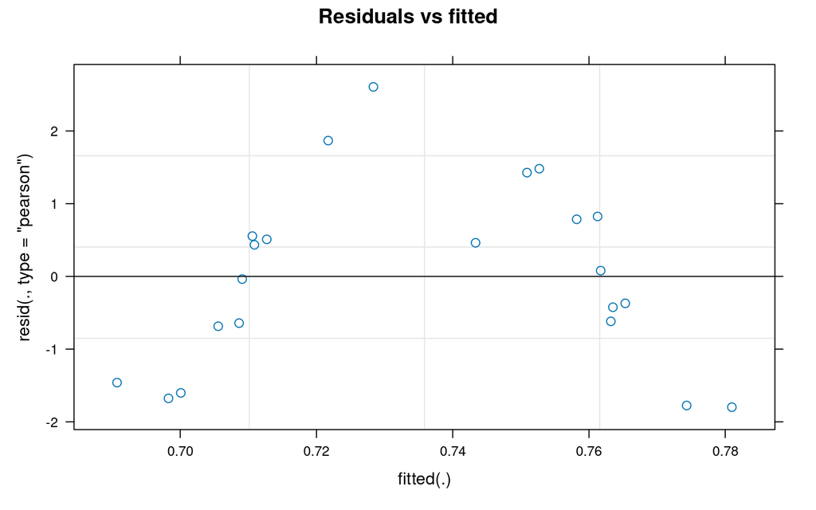

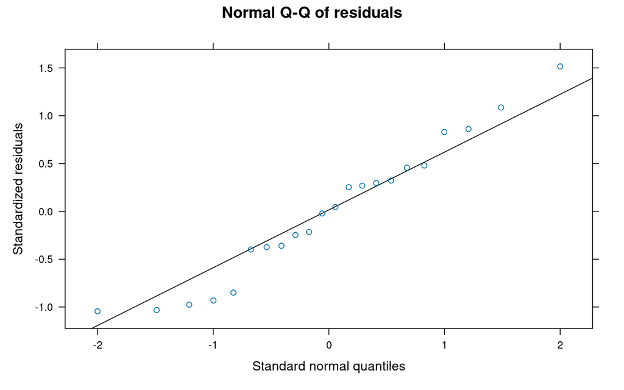

```r
diag_lmer(fit_hi_3_5)
```

### Pipeline 3 so far

```r
show_rows(hc, est_tbl %>% filter(comparison == hc, pipeline %in% c("1", "2", "3")) %>% pull(model))
```

| model | scale | estimate (model scale) | SE (model scale) | σ | Δ AUC | SE (AUC) | 95% CI | note |
| --- | --- | --- | --- | --- | --- | --- | --- | --- |
| 1. IVW stage 1 → stage 2 | AUC | 0.05261 | 0.00130 | NA | 0.05261 | 0.00130 | 0.0501 to 0.0552 |  |
| 2.1 lm(logit ~ ancestry), weighted | logit | 0.27278 | 0.02876 | 4.17022 | 0.05300 | 0.00544 | 0.0423 to 0.0637 |  |
| 2.2 lm(logit ~ ancestry + PGS) | logit | 0.27099 | 0.00980 | 0.02298 | 0.05261 | 0.00190 | 0.0489 to 0.0563 |  |
| 2.3 lm(logit ~ ancestry + PGS), weighted | logit | 0.27162 | 0.00978 | 1.41594 | 0.05273 | 0.00185 | 0.0491 to 0.0563 |  |
| 2.4 lmer(logit ~ ancestry + PGS + (1\|cohort)), weighted | logit | 0.27162 | 8.48726 | 1.41594 | 0.05273 | 1.64926 | -3.1798 to 3.2853 |  |
| 2.5 lmer(logit ~ ancestry + (1\|PGS) + (1\|cohort)), weighted | logit | 0.27170 | 7.96186 | 1.41633 | 0.05276 | 1.54764 | -2.9806 to 3.0861 | convergence warning |
| 3.1 lm(AUC ~ ancestry), weighted | AUC | 0.05269 | 0.00546 | 4.19087 | 0.05269 | 0.00546 | 0.0420 to 0.0634 |  |
| 3.2 lm(AUC ~ ancestry + PGS) | AUC | 0.05273 | 0.00222 | 0.00521 | 0.05273 | 0.00222 | 0.0484 to 0.0571 |  |
| 3.3 lm(AUC ~ ancestry + PGS), weighted | AUC | 0.05261 | 0.00224 | 1.71835 | 0.05261 | 0.00224 | 0.0482 to 0.0570 |  |
| 3.4 lmer(AUC ~ ancestry + PGS + (1\|cohort)), weighted | AUC | 0.05261 | 34.67237 | 1.71835 | 0.05261 | 34.67237 | -67.9052 to 68.0105 |  |
| 3.5 lmer(AUC ~ ancestry + (1\|PGS) + (1\|cohort)), weighted | AUC | 0.05262 | 27.36969 | 1.71975 | 0.05262 | 27.36969 | -53.5920 to 53.6972 | convergence warning |

## Pipeline 4: logit scale, `rma.mv`

```r
fit_hi_4_1 <- rma.mv(logit_auc, se_logit^2, mods = ~ ancestry, data = hi)
fit_hi_4_2 <- rma.mv(logit_auc, se_logit^2, mods = ~ ancestry + PGS, data = hi)
fit_hi_4_3 <- rma.mv(logit_auc, se_logit^2, mods = ~ ancestry + PGS, random = ~ 1 | cohort, data = hi)
fit_hi_4_4 <- rma.mv(logit_auc, se_logit^2, mods = ~ ancestry, random = list(~ 1 | PGS, ~ 1 | cohort), data = hi)
```

### 4.1 Ancestry only

```r
fit_hi_4_1
```

```
Multivariate Meta-Analysis Model (k = 22; method: REML)

Variance Components: none

Test for Residual Heterogeneity:
QE(df = 20) = 347.8155, p-val < .0001

Test of Moderators (coefficient 2):
QM(df = 1) = 1564.0258, p-val < .0001

Model Results:

                                    estimate      se      zval    pval   ci.lb   ci.ub
intrcpt                               0.8879  0.0037  243.1217  <.0001  0.8807  0.8951  ***
ancestryHispanic or Latin American    0.2728  0.0069   39.5478  <.0001  0.2593  0.2863  ***

---
Signif. codes:  0 '***' 0.001 '**' 0.01 '*' 0.05 '.' 0.1 ' ' 1
```

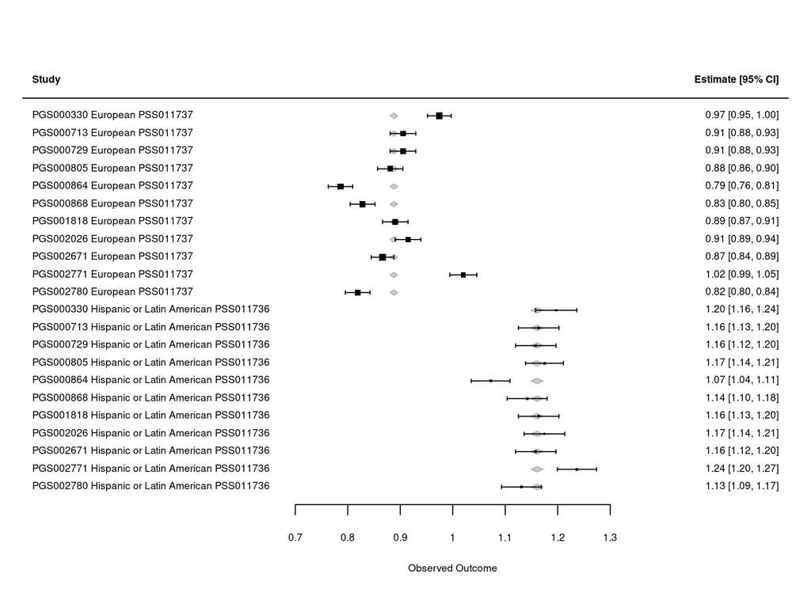

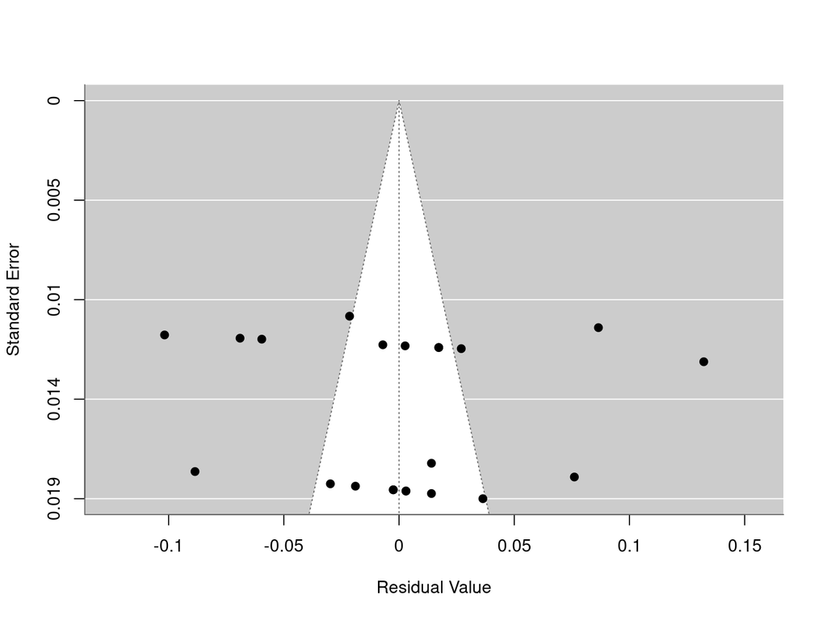

```r
diag_rma(fit_hi_4_1, hi)
```

### 4.2 Add the score

```r
fit_hi_4_2
```

```
Multivariate Meta-Analysis Model (k = 22; method: REML)

Variance Components: none

Test for Residual Heterogeneity:
QE(df = 10) = 20.0488, p-val = 0.0288

Test of Moderators (coefficients 2:12):
QM(df = 11) = 1891.7925, p-val < .0001

Model Results:

                                    estimate      se      zval    pval    ci.lb    ci.ub
intrcpt                               0.9622  0.0101   94.8874  <.0001   0.9424   0.9821  ***
ancestryHispanic or Latin American    0.2716  0.0069   39.3311  <.0001   0.2581   0.2852  ***
PGSPGS000713                         -0.0609  0.0145   -4.1934  <.0001  -0.0893  -0.0324  ***
PGSPGS000729                         -0.0624  0.0145   -4.3049  <.0001  -0.0909  -0.0340  ***
PGSPGS000805                         -0.0745  0.0143   -5.2057  <.0001  -0.1026  -0.0465  ***
PGSPGS000864                         -0.1720  0.0142  -12.1447  <.0001  -0.1998  -0.1443  ***
PGSPGS000868                         -0.1223  0.0143   -8.5441  <.0001  -0.1504  -0.0943  ***
PGSPGS001818                         -0.0713  0.0145   -4.9235  <.0001  -0.0997  -0.0429  ***
PGSPGS002026                         -0.0507  0.0145   -3.4855  0.0005  -0.0792  -0.0222  ***
PGSPGS002671                         -0.0910  0.0139   -6.5668  <.0001  -0.1182  -0.0639  ***
PGSPGS002771                          0.0402  0.0147    2.7340  0.0063   0.0114   0.0691   **
PGSPGS002780                         -0.1321  0.0143   -9.2485  <.0001  -0.1601  -0.1041  ***

---
Signif. codes:  0 '***' 0.001 '**' 0.01 '*' 0.05 '.' 0.1 ' ' 1
```

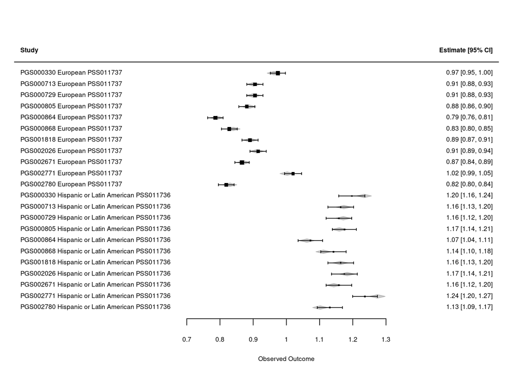

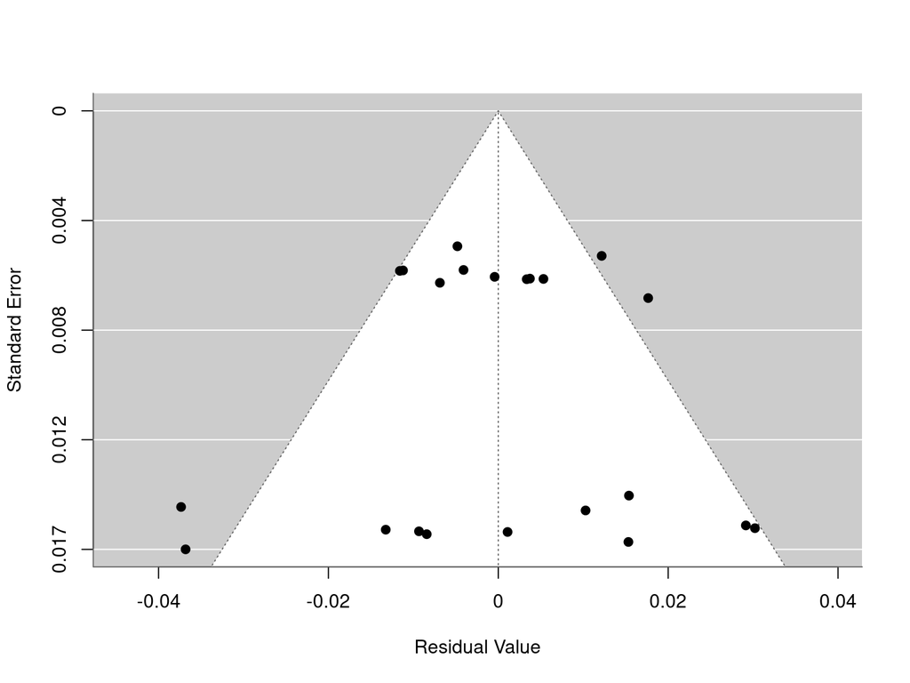

```r
diag_rma(fit_hi_4_2, hi)
```

### 4.3 Add a random effect for the sample set

```r
fit_hi_4_3
```

```
Multivariate Meta-Analysis Model (k = 22; method: REML)

Variance Components:

            estim    sqrt  nlvls  fixed  factor
sigma^2    0.0010  0.0316      2     no  cohort

Test for Residual Heterogeneity:
QE(df = 10) = 20.0488, p-val = 0.0288

Test of Moderators (coefficients 2:12):
QM(df = 11) = 364.1067, p-val < .0001

Model Results:

                                    estimate      se      zval    pval    ci.lb    ci.ub
intrcpt                               0.9622  0.0332   28.9755  <.0001   0.8972   1.0273  ***
ancestryHispanic or Latin American    0.2716  0.0453    6.0024  <.0001   0.1829   0.3603  ***
PGSPGS000713                         -0.0609  0.0145   -4.1934  <.0001  -0.0893  -0.0324  ***
PGSPGS000729                         -0.0624  0.0145   -4.3049  <.0001  -0.0909  -0.0340  ***
PGSPGS000805                         -0.0745  0.0143   -5.2057  <.0001  -0.1026  -0.0465  ***
PGSPGS000864                         -0.1720  0.0142  -12.1447  <.0001  -0.1998  -0.1443  ***
PGSPGS000868                         -0.1223  0.0143   -8.5441  <.0001  -0.1504  -0.0943  ***
PGSPGS001818                         -0.0713  0.0145   -4.9235  <.0001  -0.0997  -0.0429  ***
PGSPGS002026                         -0.0507  0.0145   -3.4855  0.0005  -0.0792  -0.0222  ***
PGSPGS002671                         -0.0910  0.0139   -6.5668  <.0001  -0.1182  -0.0639  ***
PGSPGS002771                          0.0402  0.0147    2.7340  0.0063   0.0114   0.0691   **
PGSPGS002780                         -0.1321  0.0143   -9.2485  <.0001  -0.1601  -0.1041  ***

---
Signif. codes:  0 '***' 0.001 '**' 0.01 '*' 0.05 '.' 0.1 ' ' 1
```

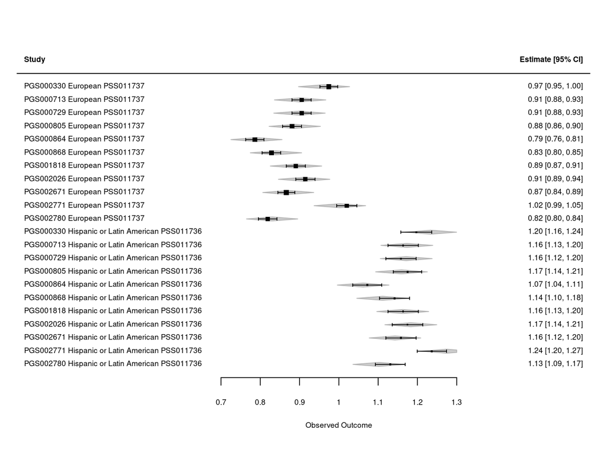

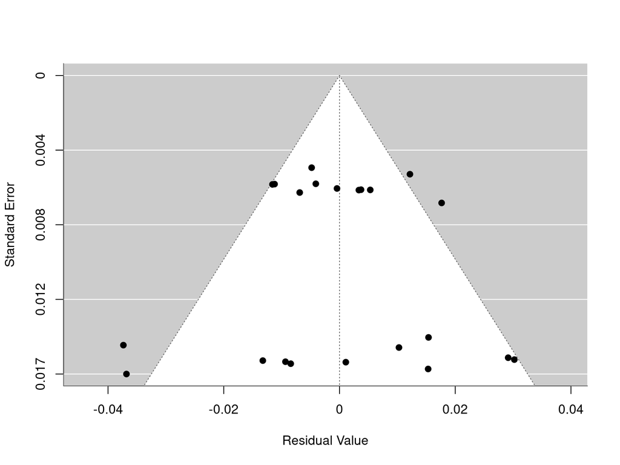

```
Profiling sigma2 = 1
```

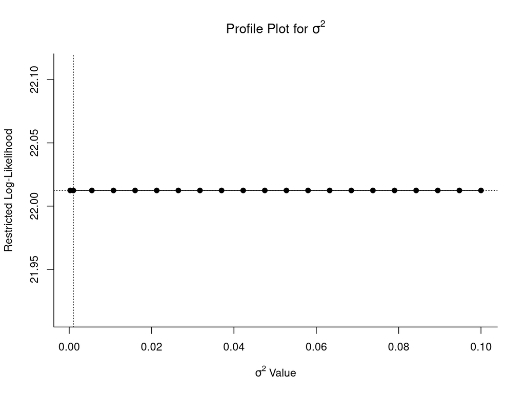

```r
diag_rma(fit_hi_4_3, hi)
```

**What we see.**

- Unlike the South Asian 4.3, the profile plot is flat.
- `rma.mv` reports a sample-set variance of 0.0010.
- The estimate, 0.2716 on the logit scale, is the same as without the random effect.

**What the metafor docs say.**

- A flat profile “suggests that at least some of the parameters of the model are not identifiable”, and the estimates are then “to some extent arbitrary” ([metafor: profile.rma](https://wviechtb.github.io/metafor/reference/profile.rma.html)).
- The documentation also has a section on overparameterised models, where it says of its example that “such models should be avoided” ([metafor: Konstantopoulos (2011) example](https://www.metafor-project.org/doku.php/analyses:konstantopoulos2011)). That example combines multilevel and multivariate random effects, which is a different case from this one, so I don’t know whether the advice applies here.

### 4.4 Score and sample set as random effects

```r
fit_hi_4_4
```

```
Multivariate Meta-Analysis Model (k = 22; method: REML)

Variance Components:

            estim    sqrt  nlvls  fixed  factor
sigma^2.1  0.0034  0.0582     11     no     PGS
sigma^2.2  0.0010  0.0316      2     no  cohort

Test for Residual Heterogeneity:
QE(df = 20) = 347.8155, p-val < .0001

Test of Moderators (coefficient 2):
QM(df = 1) = 36.0404, p-val < .0001

Model Results:

                                    estimate      se     zval    pval   ci.lb   ci.ub
intrcpt                               0.8897  0.0364  24.4748  <.0001  0.8185  0.9610  ***
ancestryHispanic or Latin American    0.2717  0.0453   6.0034  <.0001  0.1830  0.3604  ***

---
Signif. codes:  0 '***' 0.001 '**' 0.01 '*' 0.05 '.' 0.1 ' ' 1
```

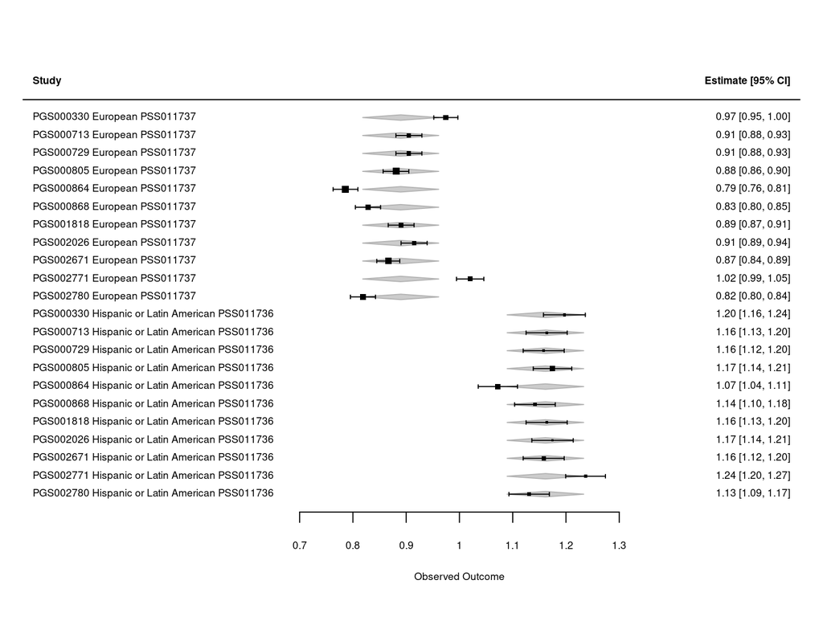

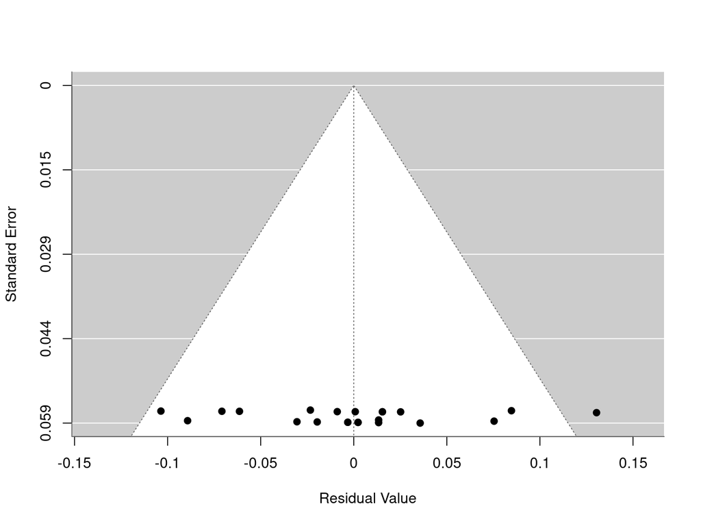

```
Profiling sigma2 = 1
```

```
Profiling sigma2 = 2
```

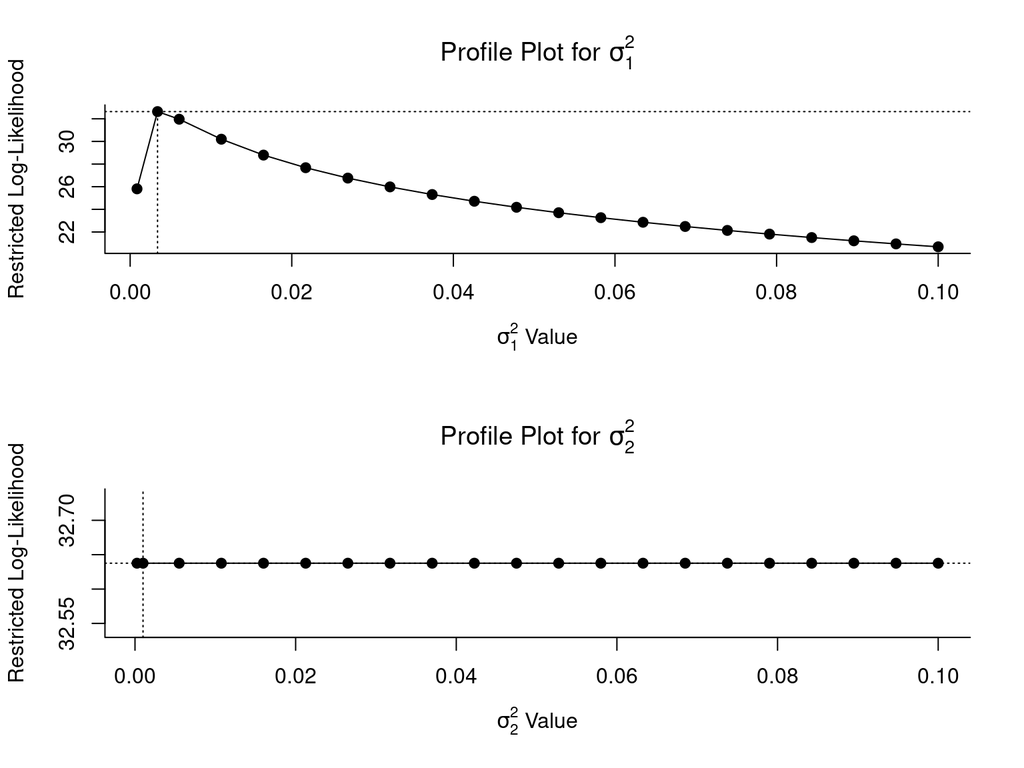

```r
diag_rma(fit_hi_4_4, hi)
```

### 4.5 A random effect for each row too

- The metafor docs say “a common mistake is to forget to add random effects at both levels”. With only the outer level, the model “assumes that the true effects for different studies within the same district are all identical” ([metafor: Konstantopoulos (2011) example](https://www.metafor-project.org/doku.php/analyses:konstantopoulos2011)). Here the district is the sample set and the studies are the rows.
- 4.3 has only the sample-set level. Following that advice, I add a random effect for each row inside its sample set: `random = ~ 1 | cohort/row`.

```r
hi$row <- factor(seq_len(nrow(hi)))
fit_hi_4_5 <- rma.mv(logit_auc, se_logit^2, mods = ~ ancestry + PGS, random = ~ 1 | cohort/row, data = hi)
record(hc, "4", "4.5 rma.mv(logit ~ ancestry + PGS, random = 1|cohort/row)", "logit", fit_hi_4_5, hi)
fit_hi_4_5
```

```
Multivariate Meta-Analysis Model (k = 22; method: REML)

Variance Components:

            estim    sqrt  nlvls  fixed      factor
sigma^2.1  0.0010  0.0316      2     no      cohort
sigma^2.2  0.0003  0.0162     22     no  cohort/row

Test for Residual Heterogeneity:
QE(df = 10) = 20.0488, p-val = 0.0288

Test of Moderators (coefficients 2:12):
QM(df = 11) = 161.1631, p-val < .0001

Model Results:

                                    estimate      se     zval    pval    ci.lb    ci.ub
intrcpt                               0.9562  0.0355  26.9188  <.0001   0.8866   1.0259  ***
ancestryHispanic or Latin American    0.2713  0.0458   5.9264  <.0001   0.1816   0.3610  ***
PGSPGS000713                         -0.0561  0.0224  -2.5008  0.0124  -0.1001  -0.0121    *
PGSPGS000729                         -0.0583  0.0224  -2.5983  0.0094  -0.1022  -0.0143   **
PGSPGS000805                         -0.0662  0.0222  -2.9756  0.0029  -0.1098  -0.0226   **
PGSPGS000864                         -0.1643  0.0222  -7.3998  <.0001  -0.2078  -0.1208  ***
PGSPGS000868                         -0.1115  0.0223  -4.9953  <.0001  -0.1553  -0.0678  ***
PGSPGS001818                         -0.0650  0.0224  -2.8988  0.0037  -0.1089  -0.0211   **
PGSPGS002026                         -0.0458  0.0225  -2.0400  0.0414  -0.0899  -0.0018    *
PGSPGS002671                         -0.0822  0.0221  -3.7133  0.0002  -0.1256  -0.0388  ***
PGSPGS002771                          0.0415  0.0225   1.8447  0.0651  -0.0026   0.0856    .
PGSPGS002780                         -0.1215  0.0223  -5.4468  <.0001  -0.1652  -0.0778  ***

---
Signif. codes:  0 '***' 0.001 '**' 0.01 '*' 0.05 '.' 0.1 ' ' 1
```

```r
profile(fit_hi_4_5)
```

```
Profiling sigma2 = 1
```

```
Profiling sigma2 = 2
```

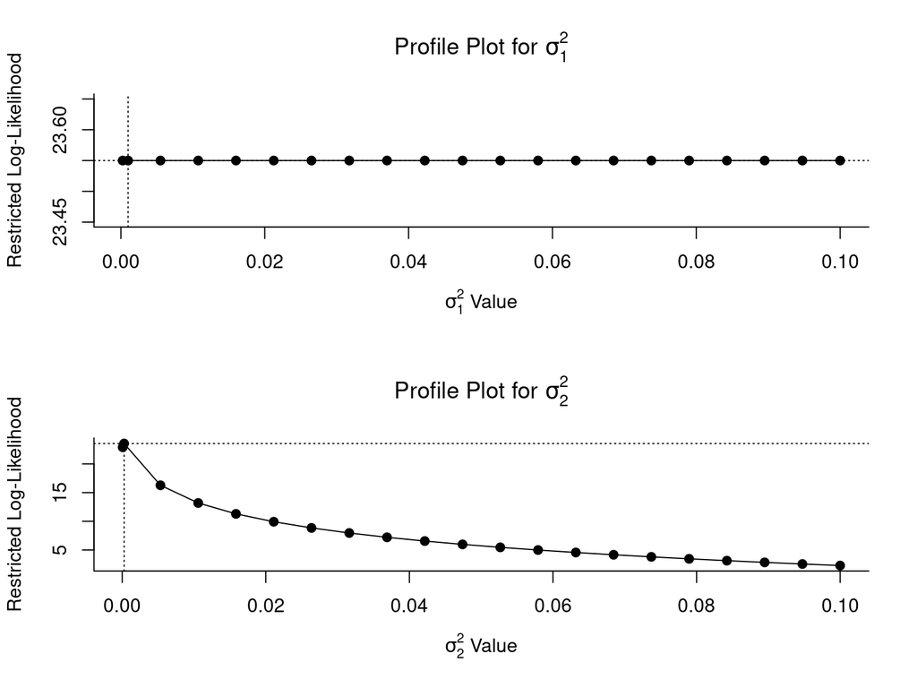

**What we see.**

- The row-level variance is estimated at 0.0003.
- Δ AUC = 0.0527, close to 4.3 (0.0527).
- The sample-set variance is still 0.0010, the value from 4.3 that the data cannot identify. The SE of Δ AUC (0.0089) depends on it, so I read the size of that SE as arbitrary too.

### 4.6 Rows that share participants

- The metafor docs say standard models “assume that the effect size estimates (or more precisely, their sampling errors) are independent” ([metafor: vcalc](https://wviechtb.github.io/metafor/reference/vcalc.html)). Rows from the same study can share people, so that assumption may not hold here.
- The recommended workflow is to build the variance-covariance matrix V with `vcalc()`, fit `rma.mv()` with it, and then use `robust()` with clubSandwich, “since V is often only a rough approximation” ([metafor: recommended practices](https://wviechtb.github.io/metafor/reference/misc-recs.html)).
- I don’t know the correlation between the sampling errors of rows from the same source study, so I assume ρ = 0.6, an intermediate value between 0 (independent) and 1. In `09_review_sensitivity.R` I also try 0, 0.3 and 0.9. I would value advice on what value is reasonable here.
- With `cluster = study`, ρ also applies between European and Hispanic or Latin American rows of the same study, and those rows cannot share people. Here all 22 rows come from All of Us, so every European row is correlated with every Hispanic or Latin American row. `vcalc()` has a `subgroup` argument for “(independent) subgroups within clusters”, which I do not use here (open question 3).
- `robust()` then clusters on the study. I only take the robust interval as usable when it has at least 4 degrees of freedom. That threshold is also my choice, and I am open to advice on it.
- The same page warns that with few clusters the degrees of freedom can be very low.

```r
V_hi <- vcalc(se_logit^2, cluster = study, obs = row, rho = 0.6, data = hi)
fit_hi_4_6 <- rma.mv(logit_auc, V_hi, mods = ~ ancestry + PGS, random = ~ 1 | cohort/row, data = hi)
record(hc, "4", "4.6 rma.mv(logit ~ ancestry + PGS, random = 1|cohort/row), V with rho = 0.6 within study", "logit", fit_hi_4_6, hi)
fit_hi_4_6
```

```
Multivariate Meta-Analysis Model (k = 22; method: REML)

Variance Components:

            estim    sqrt  nlvls  fixed      factor
sigma^2.1  0.0010  0.0316      2     no      cohort
sigma^2.2  0.0004  0.0206     22     no  cohort/row

Test for Residual Heterogeneity:
QE(df = 10) = 50.1181, p-val < .0001

Test of Moderators (coefficients 2:12):
QM(df = 11) = 147.3358, p-val < .0001

Model Results:

                                    estimate      se     zval    pval    ci.lb    ci.ub
intrcpt                               0.9525  0.0370  25.7463  <.0001   0.8800   1.0250  ***
ancestryHispanic or Latin American    0.2710  0.0461   5.8761  <.0001   0.1806   0.3614  ***
PGSPGS000713                         -0.0533  0.0229  -2.3230  0.0202  -0.0982  -0.0083    *
PGSPGS000729                         -0.0558  0.0229  -2.4332  0.0150  -0.1007  -0.0108    *
PGSPGS000805                         -0.0612  0.0228  -2.6818  0.0073  -0.1060  -0.0165   **
PGSPGS000864                         -0.1597  0.0228  -6.9951  <.0001  -0.2044  -0.1149  ***
PGSPGS000868                         -0.1050  0.0229  -4.5902  <.0001  -0.1499  -0.0602  ***
PGSPGS001818                         -0.0612  0.0229  -2.6696  0.0076  -0.1061  -0.0163   **
PGSPGS002026                         -0.0429  0.0229  -1.8698  0.0615  -0.0878   0.0021    .
PGSPGS002671                         -0.0769  0.0228  -3.3695  0.0008  -0.1217  -0.0322  ***
PGSPGS002771                          0.0422  0.0229   1.8417  0.0655  -0.0027   0.0871    .
PGSPGS002780                         -0.1151  0.0229  -5.0325  <.0001  -0.1599  -0.0703  ***

---
Signif. codes:  0 '***' 0.001 '**' 0.01 '*' 0.05 '.' 0.1 ' ' 1
```

```r
rob_hi_4_6 <- tryCatch(
  robust(fit_hi_4_6, cluster = hi$study, clubSandwich = TRUE),
  error = function(e) { cat("robust() could not be fitted:", conditionMessage(e), "\n"); NULL }
)
```

```
robust() could not be fitted: Could not obtain the cluster-robust variance-covariance matrix (use verbose=TRUE for more details).
```

```r
rob_hi_df <- if (is.null(rob_hi_4_6)) NA_real_ else unname(rob_hi_4_6$ddf[2])
if (!is.null(rob_hi_4_6)) print(rob_hi_4_6)
# The robust interval is used only with at least 4 degrees of freedom (my threshold, open to advice).
if (isTRUE(rob_hi_df >= 4)) record(hc, "4", "4.6 robust(), clustered on study", "logit", rob_hi_4_6, hi)
c(studies = n_distinct(hi$study), robust_df_ancestry = rob_hi_df)
```

```
           studies robust_df_ancestry
                 1                 NA
```

The profile plots for the two variance components of this model:

```r
profile(fit_hi_4_6)
```

```
Profiling sigma2 = 1
```

```
Profiling sigma2 = 2
```

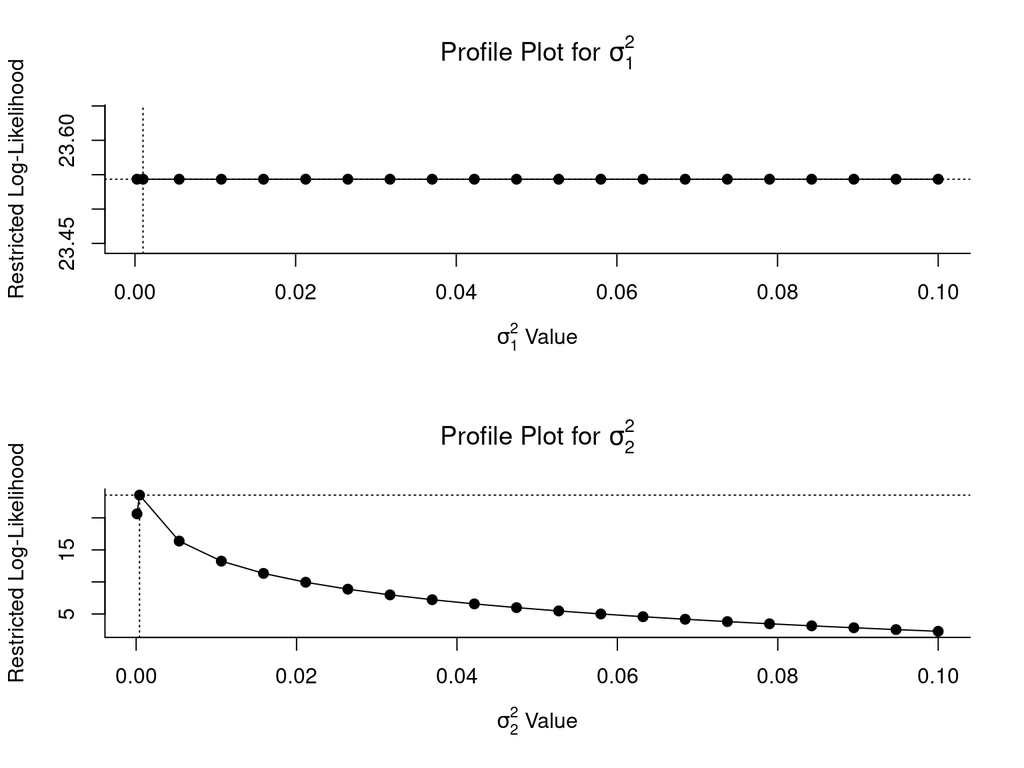

**What we see.**

- With V, Δ AUC = 0.0526 (SE 0.0089), close to 4.5 (0.0527).
- As in 4.5, the SE depends on a sample-set variance the data cannot identify, so its size is arbitrary.
- All 22 rows come from 1 study, so `robust()` has a single cluster and could not be fitted.

## Pipeline 5: AUC scale, `rma.mv`

```r
fit_hi_5_1 <- rma.mv(auc, se_auc^2, mods = ~ ancestry, data = hi)
fit_hi_5_2 <- rma.mv(auc, se_auc^2, mods = ~ ancestry + PGS, data = hi)
fit_hi_5_3 <- rma.mv(auc, se_auc^2, mods = ~ ancestry + PGS, random = ~ 1 | cohort, data = hi)
fit_hi_5_4 <- rma.mv(auc, se_auc^2, mods = ~ ancestry, random = list(~ 1 | PGS, ~ 1 | cohort), data = hi)
```

### 5.1 Ancestry only

```r
fit_hi_5_1
```

```
Multivariate Meta-Analysis Model (k = 22; method: REML)

Variance Components: none

Test for Residual Heterogeneity:
QE(df = 20) = 351.2681, p-val < .0001

Test of Moderators (coefficient 2):
QM(df = 1) = 1637.6341, p-val < .0001

Model Results:

                                    estimate      se      zval    pval   ci.lb   ci.ub
intrcpt                               0.7090  0.0008  941.3630  <.0001  0.7075  0.7105  ***
ancestryHispanic or Latin American    0.0527  0.0013   40.4677  <.0001  0.0501  0.0552  ***

---
Signif. codes:  0 '***' 0.001 '**' 0.01 '*' 0.05 '.' 0.1 ' ' 1
```

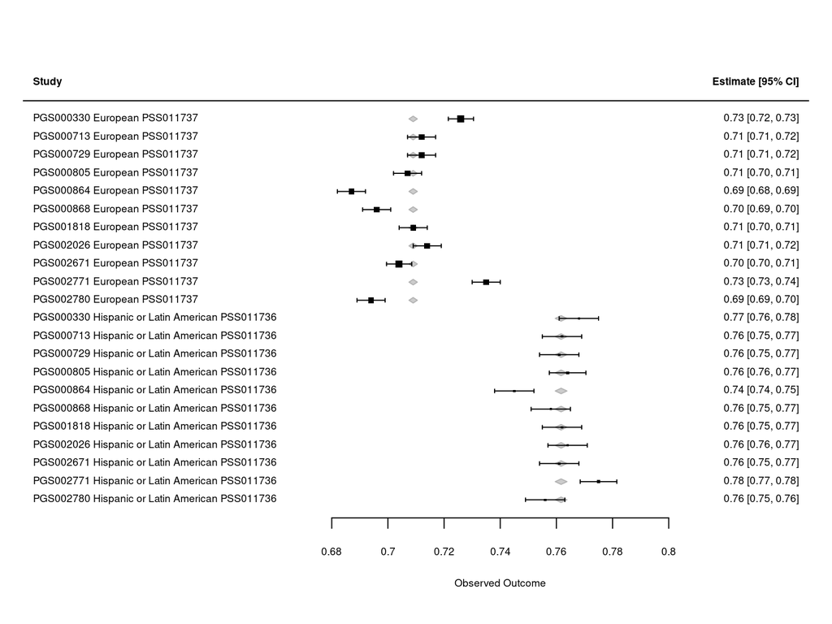

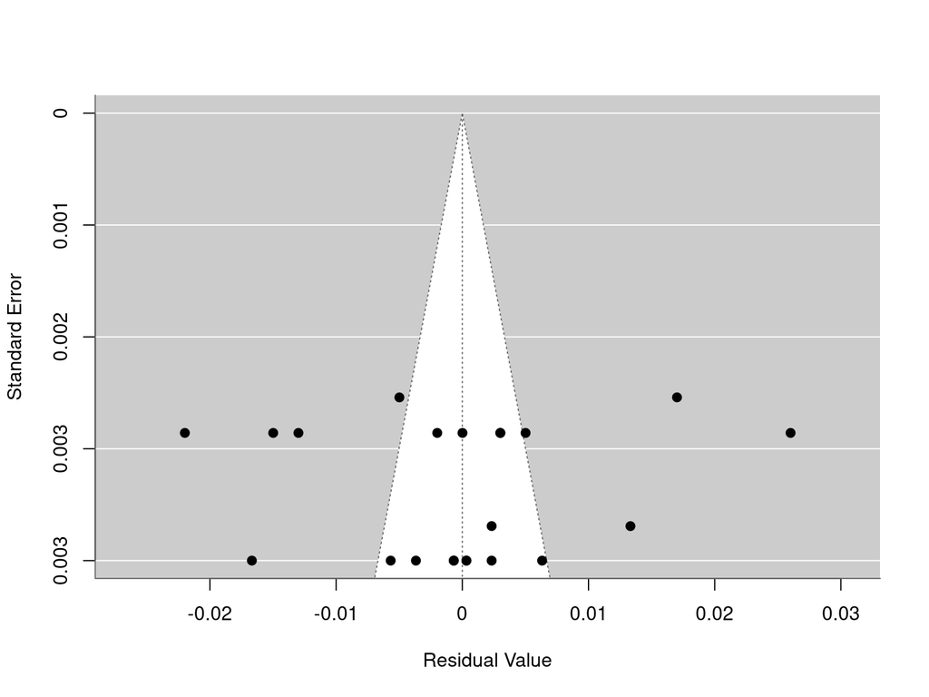

```r
diag_rma(fit_hi_5_1, hi)
```

### 5.2 Add the score

```r
fit_hi_5_2
```

```
Multivariate Meta-Analysis Model (k = 22; method: REML)

Variance Components: none

Test for Residual Heterogeneity:
QE(df = 10) = 29.5273, p-val = 0.0010

Test of Moderators (coefficients 2:12):
QM(df = 11) = 1959.3749, p-val < .0001

Model Results:

                                    estimate      se      zval    pval    ci.lb    ci.ub
intrcpt                               0.7229  0.0020  367.4927  <.0001   0.7190   0.7268  ***
ancestryHispanic or Latin American    0.0526  0.0013   40.3538  <.0001   0.0501   0.0552  ***
PGSPGS000713                         -0.0118  0.0028   -4.1566  <.0001  -0.0173  -0.0062  ***
PGSPGS000729                         -0.0121  0.0028   -4.2757  <.0001  -0.0177  -0.0066  ***
PGSPGS000805                         -0.0143  0.0028   -5.1016  <.0001  -0.0198  -0.0088  ***
PGSPGS000864                         -0.0341  0.0028  -12.0213  <.0001  -0.0396  -0.0285  ***
PGSPGS000868                         -0.0237  0.0028   -8.3703  <.0001  -0.0293  -0.0182  ***
PGSPGS001818                         -0.0138  0.0028   -4.8573  <.0001  -0.0193  -0.0082  ***
PGSPGS002026                         -0.0098  0.0028   -3.4512  0.0006  -0.0153  -0.0042  ***
PGSPGS002671                         -0.0176  0.0027   -6.4559  <.0001  -0.0230  -0.0123  ***
PGSPGS002771                          0.0074  0.0028    2.6513  0.0080   0.0019   0.0129   **
PGSPGS002780                         -0.0257  0.0028   -9.0757  <.0001  -0.0313  -0.0202  ***

---
Signif. codes:  0 '***' 0.001 '**' 0.01 '*' 0.05 '.' 0.1 ' ' 1
```

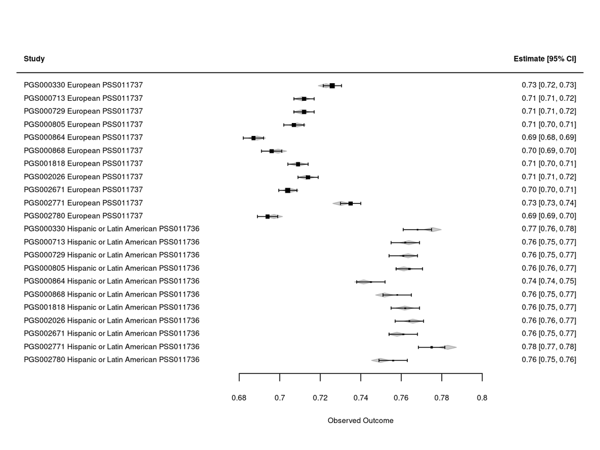

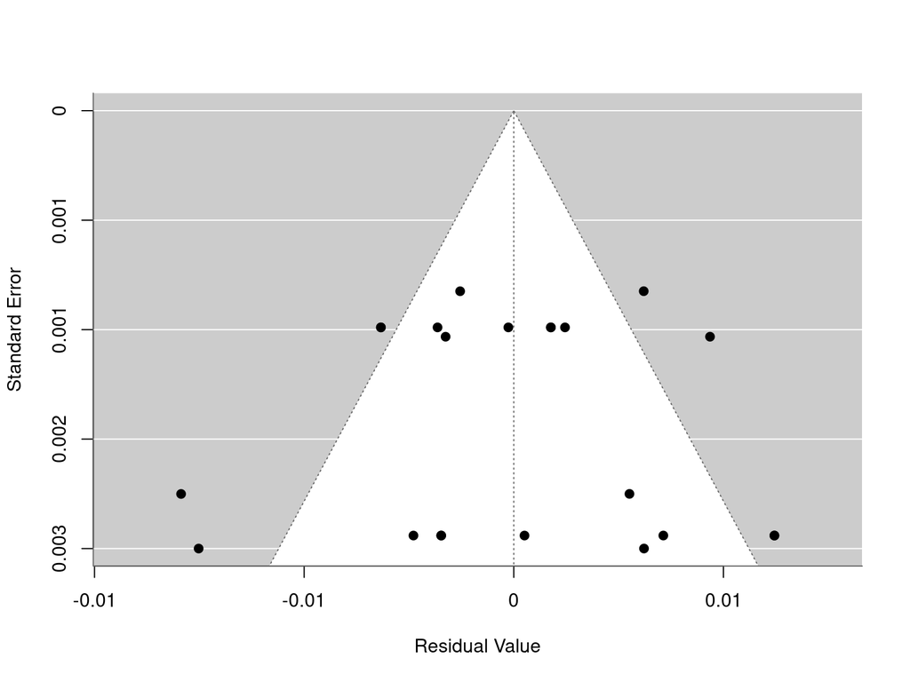

```r
diag_rma(fit_hi_5_2, hi)
```

### 5.3 Add a random effect for the sample set

```r
fit_hi_5_3
```

```
Multivariate Meta-Analysis Model (k = 22; method: REML)

Variance Components:

            estim    sqrt  nlvls  fixed  factor
sigma^2    0.0010  0.0316      2     no  cohort

Test for Residual Heterogeneity:
QE(df = 10) = 29.5273, p-val = 0.0010

Test of Moderators (coefficients 2:12):
QM(df = 11) = 323.1277, p-val < .0001

Model Results:

                                    estimate      se      zval    pval    ci.lb    ci.ub
intrcpt                               0.7229  0.0317   22.8161  <.0001   0.6608   0.7850  ***
ancestryHispanic or Latin American    0.0526  0.0447    1.1760  0.2396  -0.0351   0.1403
PGSPGS000713                         -0.0118  0.0028   -4.1566  <.0001  -0.0173  -0.0062  ***
PGSPGS000729                         -0.0121  0.0028   -4.2757  <.0001  -0.0177  -0.0066  ***
PGSPGS000805                         -0.0143  0.0028   -5.1016  <.0001  -0.0198  -0.0088  ***
PGSPGS000864                         -0.0341  0.0028  -12.0213  <.0001  -0.0396  -0.0285  ***
PGSPGS000868                         -0.0237  0.0028   -8.3703  <.0001  -0.0293  -0.0182  ***
PGSPGS001818                         -0.0138  0.0028   -4.8573  <.0001  -0.0193  -0.0082  ***
PGSPGS002026                         -0.0098  0.0028   -3.4512  0.0006  -0.0153  -0.0042  ***
PGSPGS002671                         -0.0176  0.0027   -6.4559  <.0001  -0.0230  -0.0123  ***
PGSPGS002771                          0.0074  0.0028    2.6513  0.0080   0.0019   0.0129   **
PGSPGS002780                         -0.0257  0.0028   -9.0757  <.0001  -0.0313  -0.0202  ***

---
Signif. codes:  0 '***' 0.001 '**' 0.01 '*' 0.05 '.' 0.1 ' ' 1
```

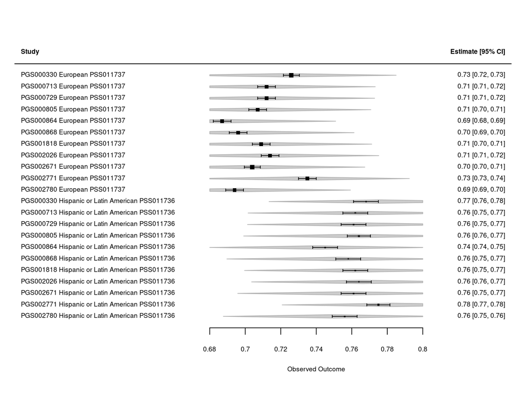

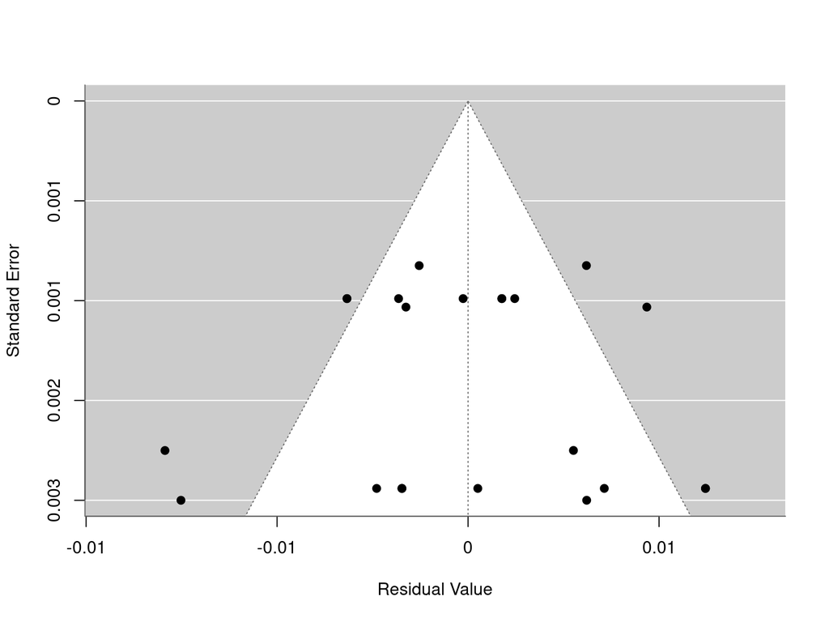

```
Profiling sigma2 = 1
```

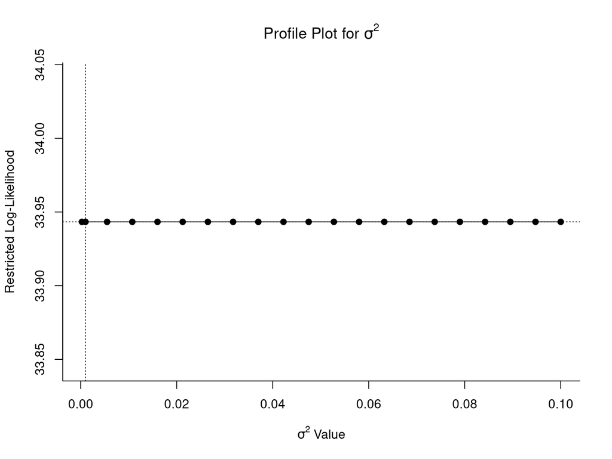

```r
diag_rma(fit_hi_5_3, hi)
```

### 5.4 Score and sample set as random effects

```r
fit_hi_5_4
```

```
Multivariate Meta-Analysis Model (k = 22; method: REML)

Variance Components:

            estim    sqrt  nlvls  fixed  factor
sigma^2.1  0.0001  0.0114     11     no     PGS
sigma^2.2  0.0010  0.0316      2     no  cohort

Test for Residual Heterogeneity:
QE(df = 20) = 351.2681, p-val < .0001

Test of Moderators (coefficient 2):
QM(df = 1) = 1.3831, p-val = 0.2396

Model Results:

                                    estimate      se     zval    pval    ci.lb   ci.ub
intrcpt                               0.7088  0.0318  22.2770  <.0001   0.6464  0.7711  ***
ancestryHispanic or Latin American    0.0526  0.0447   1.1761  0.2396  -0.0351  0.1403

---
Signif. codes:  0 '***' 0.001 '**' 0.01 '*' 0.05 '.' 0.1 ' ' 1
```

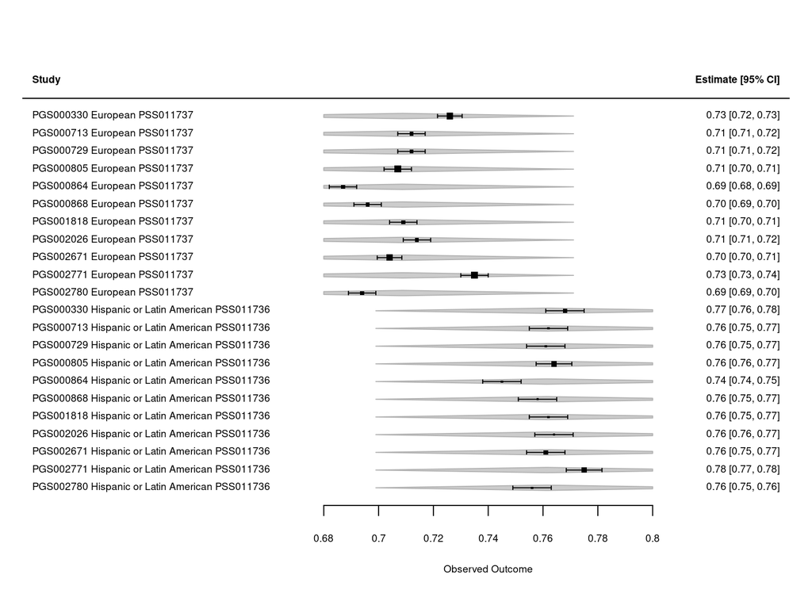

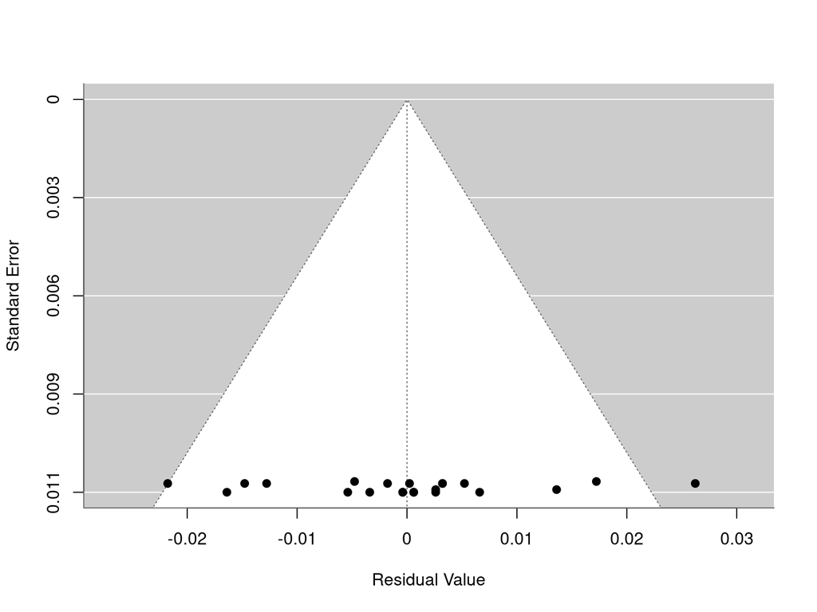

```
Profiling sigma2 = 1
```

```
Profiling sigma2 = 2
```

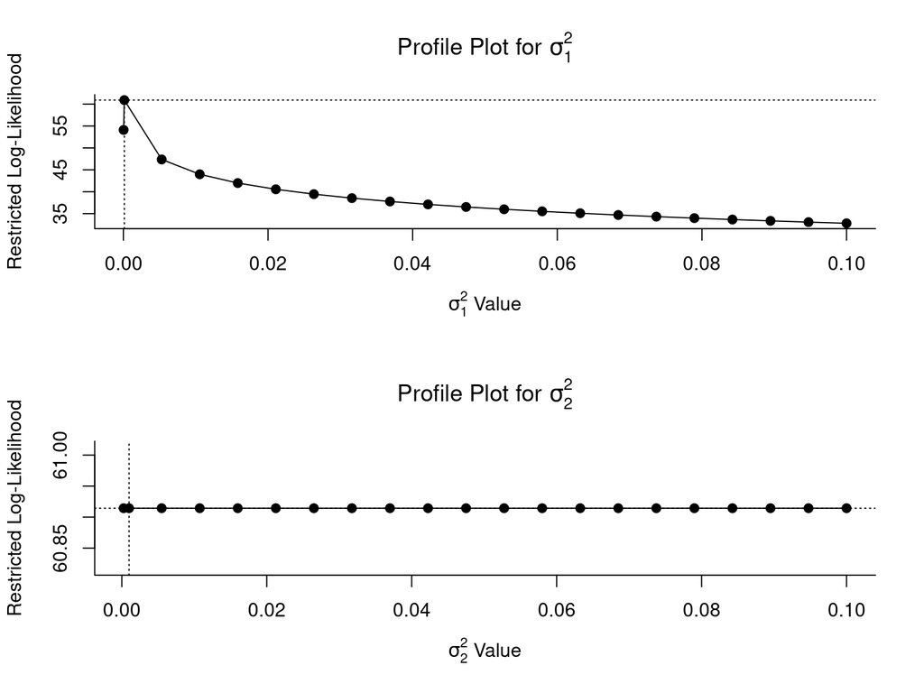

```r
diag_rma(fit_hi_5_4, hi)
```

## All Hispanic or Latin American estimates side by side

```r
show_rows(hc, est_tbl %>% filter(comparison == hc) %>% pull(model))
```

| model | scale | estimate (model scale) | SE (model scale) | σ | Δ AUC | SE (AUC) | 95% CI | note |
| --- | --- | --- | --- | --- | --- | --- | --- | --- |
| 1. IVW stage 1 → stage 2 | AUC | 0.05261 | 0.00130 | NA | 0.05261 | 0.00130 | 0.0501 to 0.0552 |  |
| 2.1 lm(logit ~ ancestry), weighted | logit | 0.27278 | 0.02876 | 4.17022 | 0.05300 | 0.00544 | 0.0423 to 0.0637 |  |
| 2.2 lm(logit ~ ancestry + PGS) | logit | 0.27099 | 0.00980 | 0.02298 | 0.05261 | 0.00190 | 0.0489 to 0.0563 |  |
| 2.3 lm(logit ~ ancestry + PGS), weighted | logit | 0.27162 | 0.00978 | 1.41594 | 0.05273 | 0.00185 | 0.0491 to 0.0563 |  |
| 2.4 lmer(logit ~ ancestry + PGS + (1\|cohort)), weighted | logit | 0.27162 | 8.48726 | 1.41594 | 0.05273 | 1.64926 | -3.1798 to 3.2853 |  |
| 2.5 lmer(logit ~ ancestry + (1\|PGS) + (1\|cohort)), weighted | logit | 0.27170 | 7.96186 | 1.41633 | 0.05276 | 1.54764 | -2.9806 to 3.0861 | convergence warning |
| 3.1 lm(AUC ~ ancestry), weighted | AUC | 0.05269 | 0.00546 | 4.19087 | 0.05269 | 0.00546 | 0.0420 to 0.0634 |  |
| 3.2 lm(AUC ~ ancestry + PGS) | AUC | 0.05273 | 0.00222 | 0.00521 | 0.05273 | 0.00222 | 0.0484 to 0.0571 |  |
| 3.3 lm(AUC ~ ancestry + PGS), weighted | AUC | 0.05261 | 0.00224 | 1.71835 | 0.05261 | 0.00224 | 0.0482 to 0.0570 |  |
| 3.4 lmer(AUC ~ ancestry + PGS + (1\|cohort)), weighted | AUC | 0.05261 | 34.67237 | 1.71835 | 0.05261 | 34.67237 | -67.9052 to 68.0105 |  |
| 3.5 lmer(AUC ~ ancestry + (1\|PGS) + (1\|cohort)), weighted | AUC | 0.05262 | 27.36969 | 1.71975 | 0.05262 | 27.36969 | -53.5920 to 53.6972 | convergence warning |
| 4.1 rma.mv(logit ~ ancestry) | logit | 0.27278 | 0.00690 | NA | 0.05300 | 0.00130 | 0.0504 to 0.0556 |  |
| 4.2 rma.mv(logit ~ ancestry + PGS) | logit | 0.27162 | 0.00691 | NA | 0.05273 | 0.00130 | 0.0502 to 0.0553 |  |
| 4.3 rma.mv(logit ~ ancestry + PGS, random = 1\|cohort) | logit | 0.27162 | 0.04525 | NA | 0.05273 | 0.00879 | 0.0355 to 0.0700 |  |
| 4.4 rma.mv(logit ~ ancestry, random = 1\|PGS + 1\|cohort) | logit | 0.27166 | 0.04525 | NA | 0.05275 | 0.00880 | 0.0355 to 0.0700 |  |
| 4.5 rma.mv(logit ~ ancestry + PGS, random = 1\|cohort/row) | logit | 0.27130 | 0.04578 | NA | 0.05267 | 0.00889 | 0.0352 to 0.0701 |  |
| 4.6 rma.mv(logit ~ ancestry + PGS, random = 1\|cohort/row), V with rho = 0.6 within study | logit | 0.27104 | 0.04613 | NA | 0.05262 | 0.00893 | 0.0351 to 0.0701 |  |
| 5.1 rma.mv(AUC ~ ancestry) | AUC | 0.05269 | 0.00130 | NA | 0.05269 | 0.00130 | 0.0501 to 0.0552 |  |
| 5.2 rma.mv(AUC ~ ancestry + PGS) | AUC | 0.05261 | 0.00130 | NA | 0.05261 | 0.00130 | 0.0501 to 0.0552 |  |
| 5.3 rma.mv(AUC ~ ancestry + PGS, random = 1\|cohort) | AUC | 0.05261 | 0.04474 | NA | 0.05261 | 0.04474 | -0.0351 to 0.1403 |  |
| 5.4 rma.mv(AUC ~ ancestry, random = 1\|PGS + 1\|cohort) | AUC | 0.05262 | 0.04474 | NA | 0.05262 | 0.04474 | -0.0351 to 0.1403 |  |

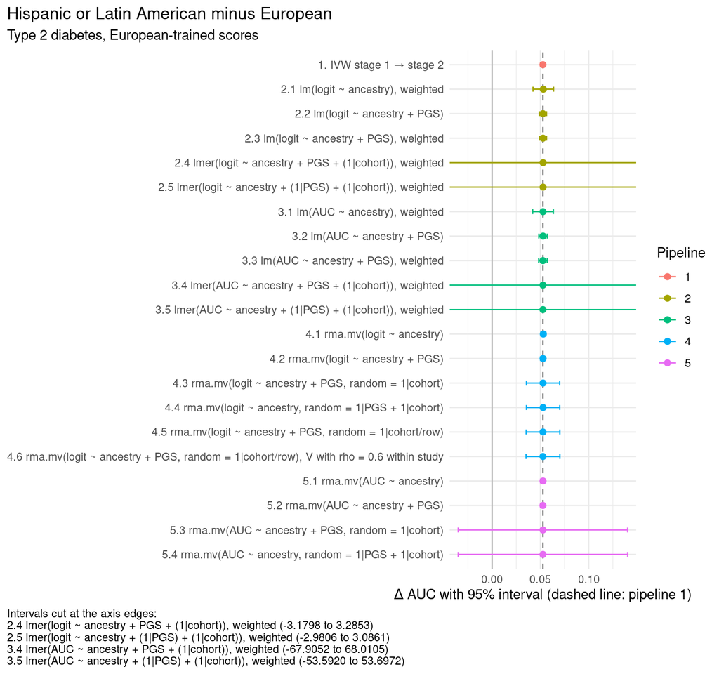

```r
# The lmer models with a sample-set term have intervals of up to ±68, which would
# hide every other model, so the x-axis is set by the remaining models.
plot_all(hc, xlim_from = function(m) !grepl("^[23]\\.[45] lmer", m))
```

- The x-axis is set by the models other than the `lmer` models with a sample-set term (2.4, 2.5, 3.4, 3.5). Their intervals run past the edges, and the caption gives them in full.

**What I take from the Hispanic or Latin American comparison.**

- Every model gives nearly the same estimate, about 0.053.
- Without a sample-set term, the SEs are small, as in pipeline 1. With one, they are much larger.
- Each ancestry group in this comparison has a single sample set.
- I don’t think the data determine how much larger. `rma.mv` reports the same sample-set variance on the logit scale (0.0010 in 4.3) and on the AUC scale (0.0010 in 5.3), and `lmer` reports 36 (2.4) and 601 (3.4).
- With a flat profile, the docs call such estimates “to some extent arbitrary” (4.3). So I read the SEs of the sample-set models as arbitrary in size.

# Comparing the two examples

The South Asian plot again, from all South Asian estimates side by side, so that both comparisons are in view here. The Hispanic or Latin American plot is just above.

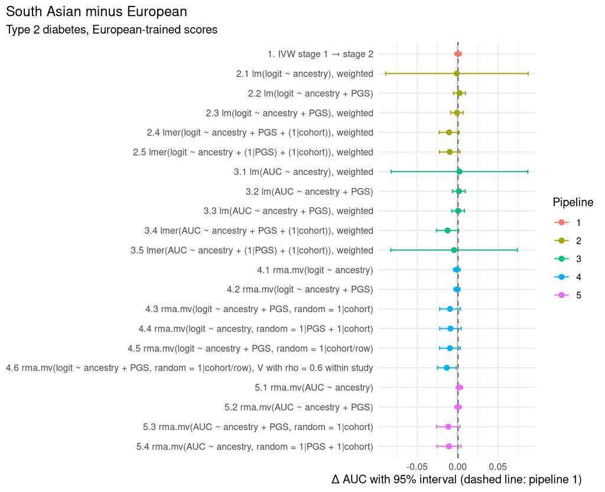

```r
plot_all("South Asian")
```

- When the sample set enters the model, the South Asian estimate moves. The Hispanic or Latin American estimate stays about the same, and its SE grows by an amount the data do not determine.
- South Asian has a few scores measured in other sample sets. Hispanic or Latin American has none.

## Open questions

1. Should the model include a sample-set term? Without one, the intervals are narrow. With one, the Hispanic or Latin American interval becomes wider by an amount the data do not determine, and the South Asian estimate moves to about -0.01 (South Asian estimates side by side, Hispanic or Latin American estimates side by side).
2. How much of each difference is ancestry and how much is the difference between the sample sets? This is the point I would most like an expert opinion on (South Asian 2.4, Hispanic or Latin American 2.4, Hispanic or Latin American 4.3).
3. What value of ρ is reasonable for rows from the same study? In South Asian 4.6, the interval excludes 0 for ρ = 0.6, 0.9 (South Asian 4.6). And should ρ apply between the ancestry groups of a study, as it does now, or only within one, with `subgroup` in `vcalc()`?
4. Should stage 2 use a random-effects model? In both examples it widens the interval, and in neither does the interval change its relation to 0. In the South Asian example it also moves the estimate, from 0.0007 to 0.0062 with REML (South Asian pipeline 1).
5. Should the tests and intervals use the t-based methods the metafor docs recommend, instead of the default z-tests used on this page (South Asian pipeline 1)?